# IQ2 Met & Flux Cleaning Script

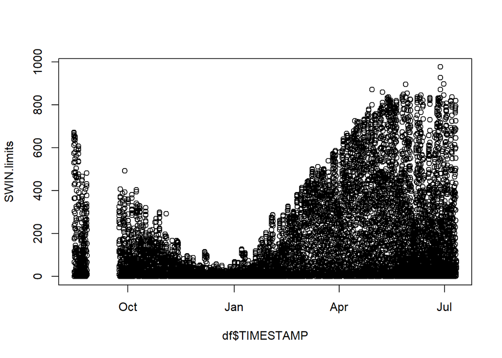

```r
plot(df$TIMESTAMP,SWIN.limits)
```

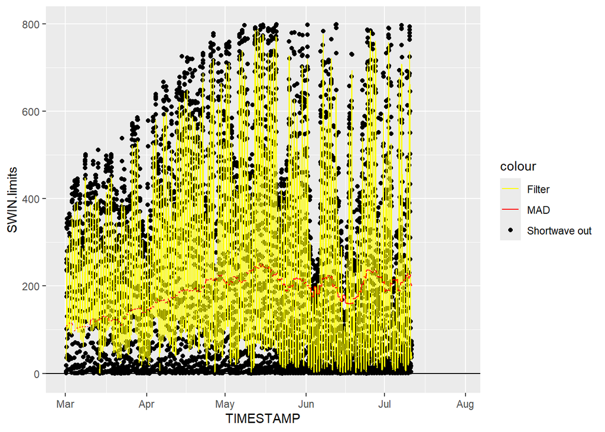

```r
f = SWIN.limits # first make a new flux vector to apply the above filters
# prepare the inputs for a zero-phase (forward and reverse) filter
ind       = which(complete.cases(f))   # first save the index of all the NAs
b         = rep(1,8)/8                 # moving average coefficient
a         = 1                          # coefficient of the ARMA filter
mad_i    = filtfilt(b, a, na.omit(f)) #create a forward and reverse ARMA filter
mad_filt = f                          # make a copy of the full fluxes again
mad_filt[ind] = mad_i                # apply the filter where the real data exist

n = 7*48 # set the length of the rolling filter, 48 half hours in day * x days
roll.mad = rollapply(data = mad_filt,
                     width = n,
                     FUN = sd,
                     partial = TRUE,
                     na.rm = T,
                     fill = NA)  #create a rolling MAD or sd or other
roll.mad[is.na(mad_filt)] = NA  #make NA values where NAs exist in the real data

ggplot(df)+geom_hline(yintercept = 0)+
  geom_point(aes(TIMESTAMP,SWIN.limits,col='Shortwave out'))+
  geom_line(aes(TIMESTAMP,mad_filt,col='Filter'))+
  geom_line(aes(TIMESTAMP,roll.mad,col='MAD'))+
  scale_y_continuous(limits = c(-5,800))+
  scale_x_datetime(limits = as.POSIXct(biomet_dates,format="%F"))+
  scale_color_manual(values=c('yellow','red','black'))
```

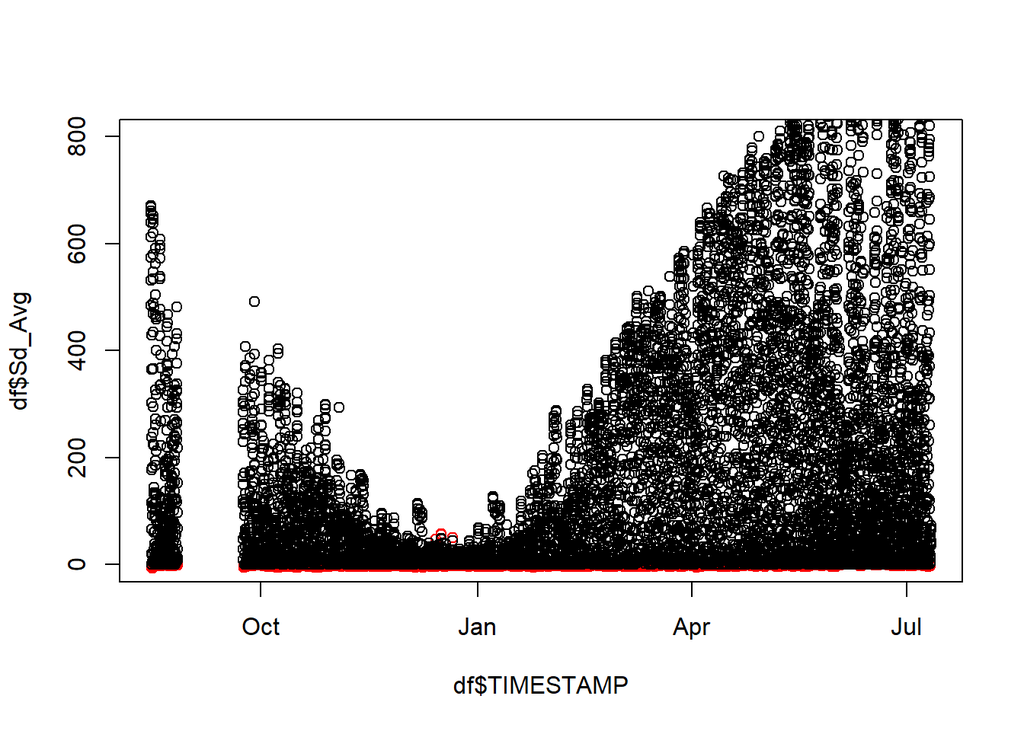

```r
#adjust this value (N) to tweak how many MADs to be away from the norm
N = 5

#Add clean value to dataframe (_.c)

df$Sd_Avg.c = ifelse(abs(SWIN.limits - mad_filt) > (N * roll.mad),NA,SWIN.limits)

#Compare cleaned vs. uncleaned

plot(df$TIMESTAMP,df$Sd_Avg,col='red',ylim = c(0,800));points(df$TIMESTAMP,df$Sd_Avg.c)
```

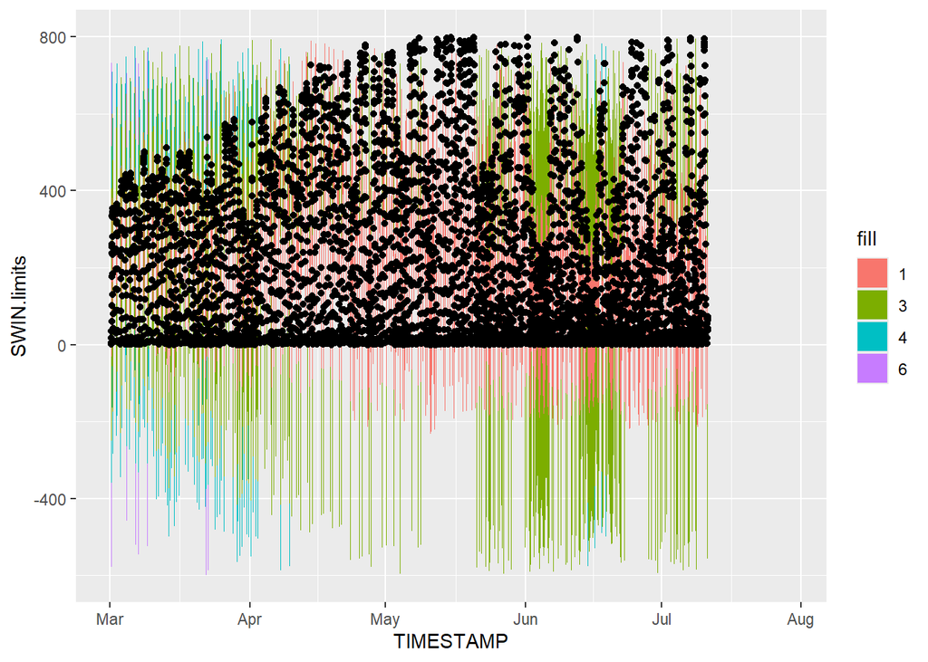

```r
ggplot(data = df)+
  geom_ribbon(aes(x = TIMESTAMP,ymax = mad_filt+roll.mad*6,ymin = mad_filt-roll.mad*6,fill='6'))+
  geom_ribbon(aes(x = TIMESTAMP,ymax = mad_filt+roll.mad*4,ymin = mad_filt-roll.mad*4,fill='4'))+
  geom_ribbon(aes(x = TIMESTAMP,ymax = mad_filt+roll.mad*3,ymin = mad_filt-roll.mad*3,fill='3'))+
  geom_ribbon(aes(x = TIMESTAMP,ymax = mad_filt+roll.mad*1,ymin = mad_filt-roll.mad*1,fill='1'))+
  geom_point(aes(TIMESTAMP,SWIN.limits),col='red')+
  geom_point(aes(TIMESTAMP,Sd_Avg.c),col='black')+
  scale_y_continuous(limits = c(-600, 800))+
  scale_x_datetime(limits = as.POSIXct(biomet_dates,format="%F"))
```

#### Albedo

Creation of variable and initial cleaning with limits

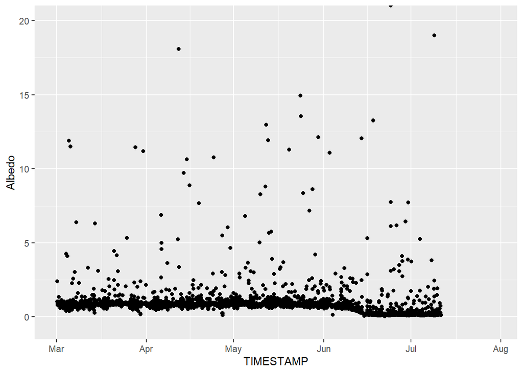

```r
albedo = df$Su_Avg.c / df$Sd_Avg.c



ggplot(data = df)+
  geom_point(aes(TIMESTAMP,albedo))+
  scale_y_continuous(limits = c(-0.5, 20),
                     expression('Albedo'))+
  scale_x_datetime(limits = as.POSIXct(biomet_dates,format="%F"))
```

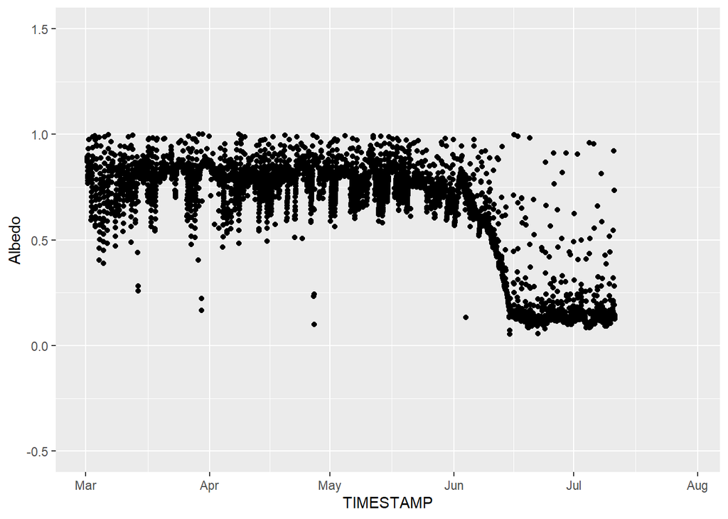

```r
albedo.limits = replace(albedo, albedo < .05 | albedo > 1,NA)


ggplot(data = df)+
  geom_point(aes(TIMESTAMP,albedo.limits))+
  scale_y_continuous(limits = c(-.5,1.5),
                     expression('Albedo'))+
  scale_x_datetime(limits = as.POSIXct(biomet_dates,format="%F"))
```

Rolling MAD

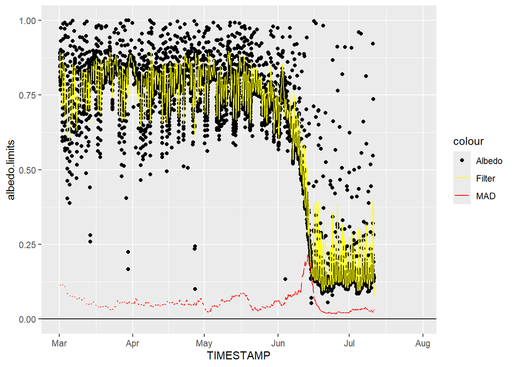

```r
f = albedo.limits # first make a new flux vector to apply the above filters
# prepare the inputs for a zero-phase (forward and reverse) filter
ind       = which(complete.cases(f))   # first save the index of all the NAs
b         = rep(1,8)/8                 # moving average coefficient
a         = 1                          # coefficient of the ARMA filter
mad_i    = filtfilt(b, a, na.omit(f)) #create a forward and reverse ARMA filter
mad_filt = f                          # make a copy of the full fluxes again
mad_filt[ind] = mad_i                # apply the filter where the real data exist

n = 7*48 # set the length of the rolling filter, 48 half hours in day * x days
roll.mad = rollapply(data = mad_filt,
                     width = n,
                     FUN = mad,
                     partial = TRUE,
                     na.rm = T,
                     fill = NA)  #create a rolling MAD or sd or other
roll.mad[is.na(mad_filt)] = NA  #make NA values where NAs exist in the real data

ggplot(df)+geom_hline(yintercept = 0)+
  geom_point(aes(TIMESTAMP,albedo.limits,col='Albedo'))+
  geom_line(aes(TIMESTAMP,mad_filt,col='Filter'))+
  geom_line(aes(TIMESTAMP,roll.mad,col='MAD'))+
  scale_y_continuous(limits = c(0,1))+
  scale_x_datetime(limits = as.POSIXct(biomet_dates,format="%F"))+
  scale_color_manual(values=c('black','yellow','red'))
```

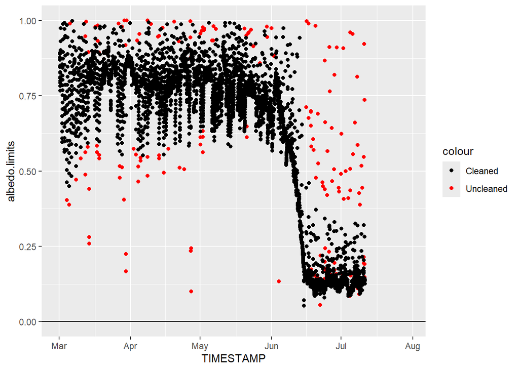

```r
#adjust this value (N) to tweak how many MADs to be away from the norm
N = 3
#Add clean value to dataframe (_.c)

df$albedo.c = ifelse(abs(albedo.limits - mad_filt) > (N * roll.mad),NA,albedo.limits)

#Compare cleaned vs. uncleaned


ggplot(df)+geom_hline(yintercept = 0)+
  geom_point(aes(TIMESTAMP,albedo.limits,col='Uncleaned'))+
  geom_point(aes(TIMESTAMP,df$albedo.c,col='Cleaned'))+
  scale_y_continuous(limits = c(0,1))+
  scale_x_datetime(limits = as.POSIXct(biomet_dates,format="%F"))+
  scale_color_manual(values=c('black','red'))
```

#### Longwave In

Looks fine, doesn’t do anything

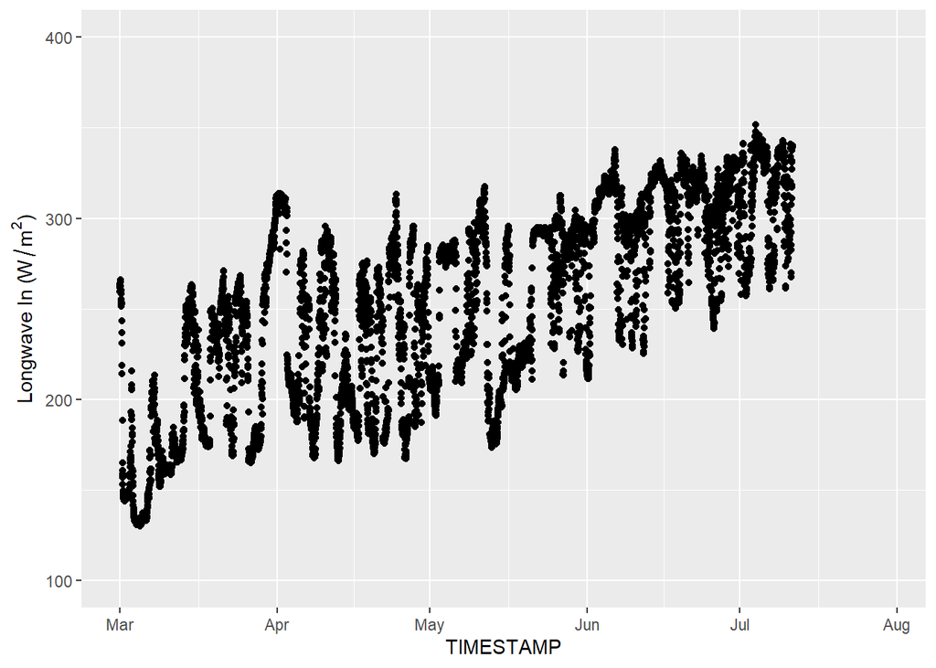

```r
ggplot(data = df)+
  geom_point(aes(TIMESTAMP,long_dn_corr_Avg))+
  scale_y_continuous(limits = c(100,400),
                     expression('Longwave In ('*W/m^2*')'))+
  scale_x_datetime(limits = as.POSIXct(biomet_dates,format="%F"))
```

```r
df$long_dn_corr_Avg.c = df$long_dn_corr_Avg
```

#### Longwave Out

Looks fine, doesn’t do anything

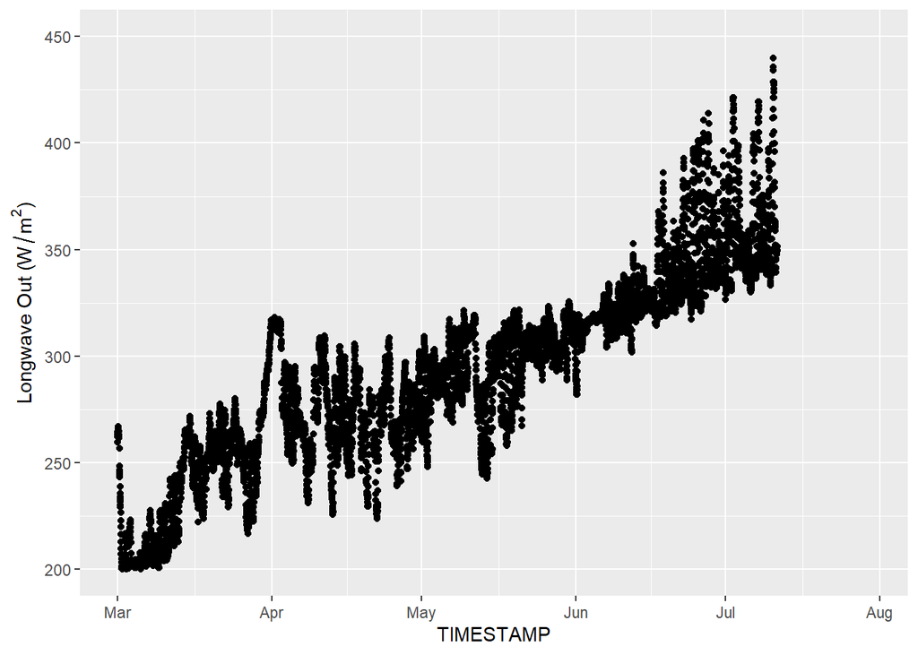

```r
ggplot(data = df)+
  geom_point(aes(TIMESTAMP,long_up_corr_Avg))+
  scale_y_continuous(limits = c(200,450),
                     expression('Longwave Out ('*W/m^2*')'))+
  scale_x_datetime(limits = as.POSIXct(biomet_dates,format="%F"))
```

```r
df$long_up_corr_Avg.c = df$long_up_corr_Avg
```

#### Net SW Avg

No initial cleaning

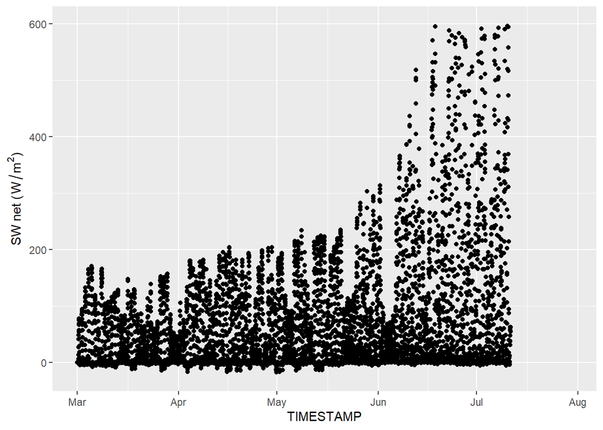

```r
ggplot(data = df)+
  geom_point(aes(TIMESTAMP,Rs_net_Avg))+
  scale_y_continuous(limits = c(-20, 600),
                     expression('SW net ('*W/m^2*')'))+
  scale_x_datetime(limits = as.POSIXct(biomet_dates,format="%F"))
```

```r
Rs_net.limits = df$Rs_net_Avg
```

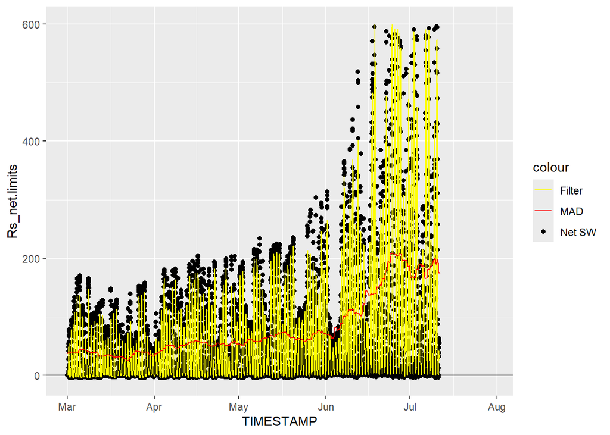

```r
f = Rs_net.limits # first make a new flux vector to apply the above filters
# prepare the inputs for a zero-phase (forward and reverse) filter
ind       = which(complete.cases(f))   # first save the index of all the NAs
b         = rep(1,8)/8                 # moving average coefficient
a         = 1                          # coefficient of the ARMA filter
mad_i    = filtfilt(b, a, na.omit(f)) #create a forward and reverse ARMA filter
mad_filt = f                          # make a copy of the full fluxes again
mad_filt[ind] = mad_i                # apply the filter where the real data exist

n = 7*48 # set the length of the rolling filter, 48 half hours in day * x days
roll.mad = rollapply(data = mad_filt,
                     width = n,
                     FUN = sd,
                     partial = TRUE,
                     na.rm = T,
                     fill = NA)  #create a rolling MAD or sd or other
roll.mad[is.na(mad_filt)] = NA  #make NA values where NAs exist in the real data

ggplot(df)+geom_hline(yintercept = 0)+
  geom_point(aes(TIMESTAMP,Rs_net.limits,col='Net SW'))+
  geom_line(aes(TIMESTAMP,mad_filt,col='Filter'))+
  geom_line(aes(TIMESTAMP,roll.mad,col='MAD'))+
  scale_y_continuous(limits = c(-5,600))+
  scale_x_datetime(limits = as.POSIXct(biomet_dates,format="%F"))+
  scale_color_manual(values=c('yellow','red','black'))
```

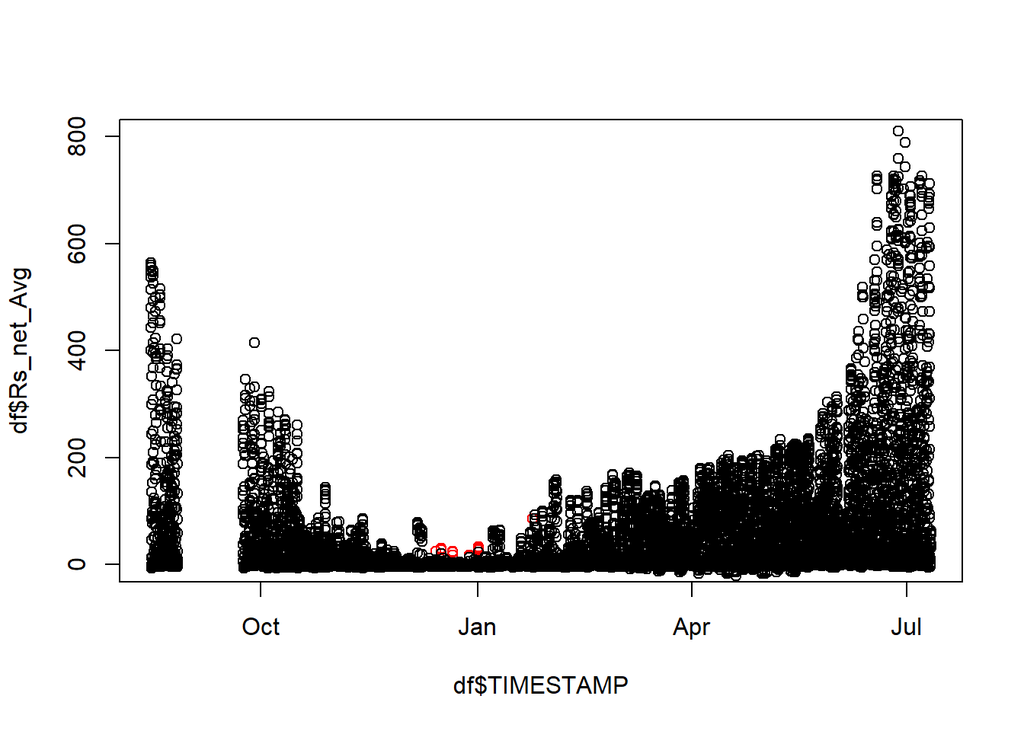

```r
#adjust this value (N) to tweak how many MADs to be away from the norm
N = 5

#Add clean value to dataframe (_.c)

df$Rs_net_Avg.c = ifelse(abs(Rs_net.limits - mad_filt) > (N * roll.mad),NA,Rs_net.limits)

#Compare cleaned vs. uncleaned

plot(df$TIMESTAMP,df$Rs_net_Avg,col='red',ylim = c(0,800));points(df$TIMESTAMP,df$Rs_net_Avg.c)
```

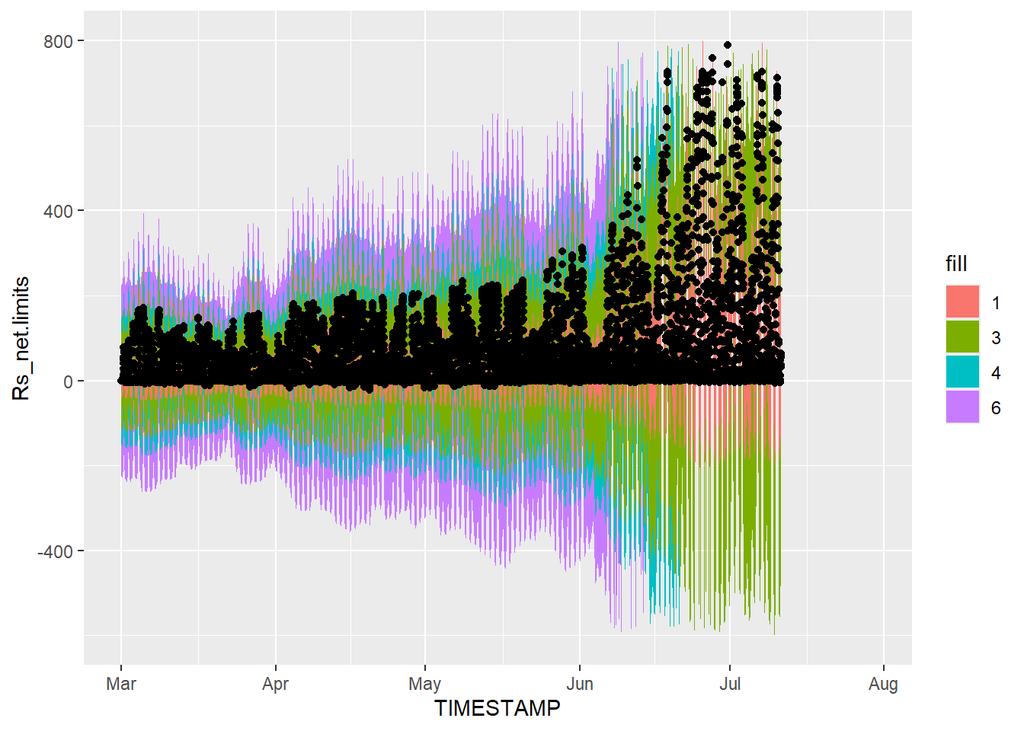

```r
ggplot(data = df)+
  geom_ribbon(aes(x = TIMESTAMP,ymax = mad_filt+roll.mad*6,ymin = mad_filt-roll.mad*6,fill='6'))+
  geom_ribbon(aes(x = TIMESTAMP,ymax = mad_filt+roll.mad*4,ymin = mad_filt-roll.mad*4,fill='4'))+
  geom_ribbon(aes(x = TIMESTAMP,ymax = mad_filt+roll.mad*3,ymin = mad_filt-roll.mad*3,fill='3'))+
  geom_ribbon(aes(x = TIMESTAMP,ymax = mad_filt+roll.mad*1,ymin = mad_filt-roll.mad*1,fill='1'))+
  geom_point(aes(TIMESTAMP,Rs_net.limits),col='red')+
  geom_point(aes(TIMESTAMP,Rs_net_Avg.c),col='black')+
  scale_y_continuous(limits = c(-600, 800))+
  scale_x_datetime(limits = as.POSIXct(biomet_dates,format="%F"))
```

#### Net LW Avg

Doesn’t do anything

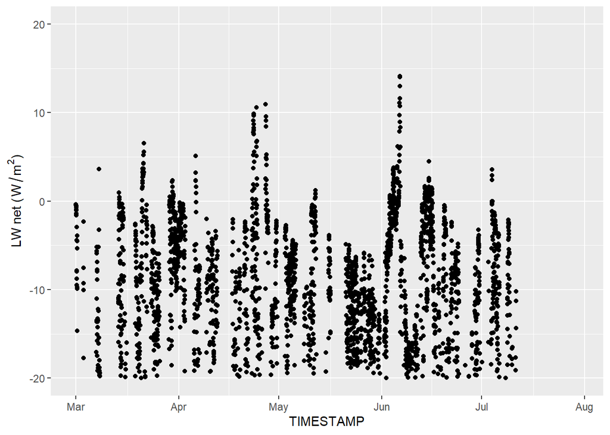

```r
ggplot(data = df)+
  geom_point(aes(TIMESTAMP,Rl_net_Avg))+
  scale_y_continuous(limits = c(-20, 20),
                     expression('LW net ('*W/m^2*')'))+
  scale_x_datetime(limits = as.POSIXct(biomet_dates,format="%F"))
```

```r
Rl_net.limits = df$Rl_net_Avg
```

Rolling SD (doesn’t do anything, left for future use)

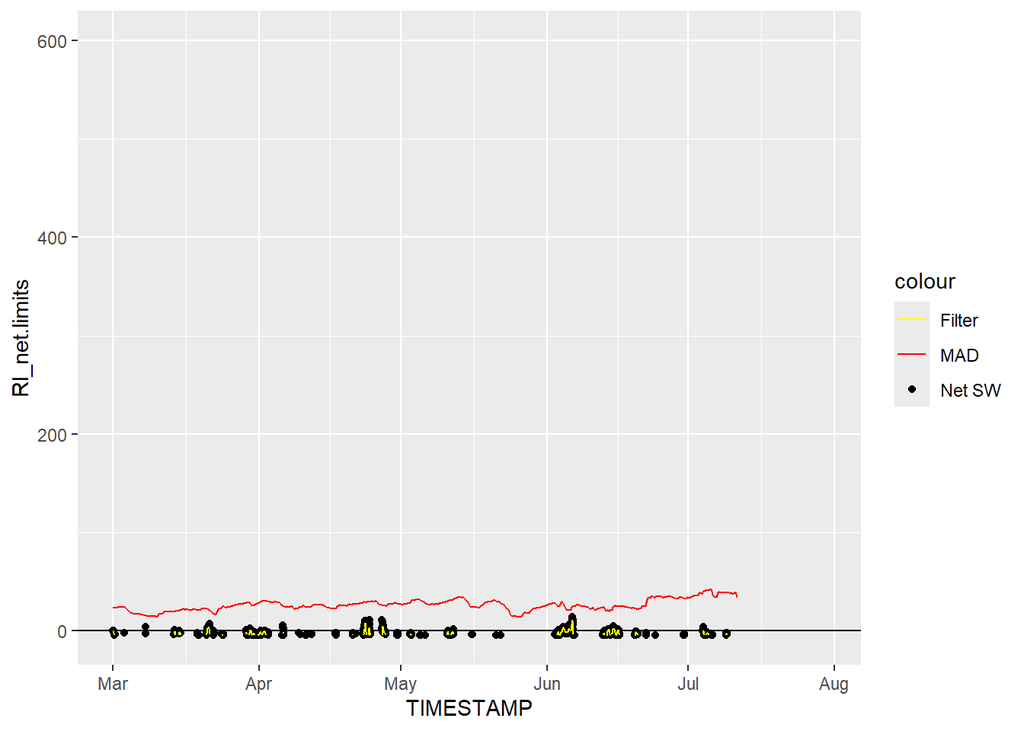

```r
f = Rl_net.limits # first make a new flux vector to apply the above filters
# prepare the inputs for a zero-phase (forward and reverse) filter
ind       = which(complete.cases(f))   # first save the index of all the NAs
b         = rep(1,8)/8                 # moving average coefficient
a         = 1                          # coefficient of the ARMA filter
mad_i    = filtfilt(b, a, na.omit(f)) #create a forward and reverse ARMA filter
mad_filt = f                          # make a copy of the full fluxes again
mad_filt[ind] = mad_i                # apply the filter where the real data exist

n = 7*48 # set the length of the rolling filter, 48 half hours in day * x days
roll.mad = rollapply(data = mad_filt,
                     width = n,
                     FUN = sd,
                     partial = TRUE,
                     na.rm = T,
                     fill = NA)  #create a rolling MAD or sd or other
roll.mad[is.na(mad_filt)] = NA  #make NA values where NAs exist in the real data

ggplot(df)+geom_hline(yintercept = 0)+
  geom_point(aes(TIMESTAMP,Rl_net.limits,col='Net SW'))+
  geom_line(aes(TIMESTAMP,mad_filt,col='Filter'))+
  geom_line(aes(TIMESTAMP,roll.mad,col='MAD'))+
  scale_y_continuous(limits = c(-5,600))+
  scale_x_datetime(limits = as.POSIXct(biomet_dates,format="%F"))+
  scale_color_manual(values=c('yellow','red','black'))
```

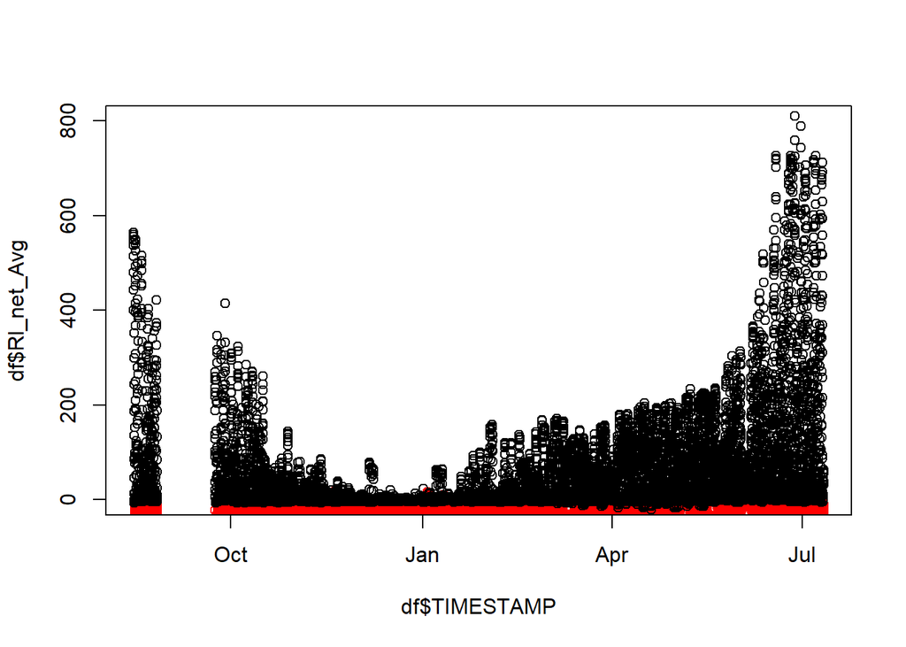

```r
#adjust this value (N) to tweak how many MADs to be away from the norm
N = 5

#Add clean value to dataframe (_.c)

df$Rl_net_Avg.c = ifelse(abs(Rl_net.limits - mad_filt) > (N * roll.mad),NA,Rl_net.limits)

#Compare cleaned vs. uncleaned

plot(df$TIMESTAMP,df$Rl_net_Avg,col='red',ylim = c(0,800));points(df$TIMESTAMP,df$Rs_net_Avg.c)
```

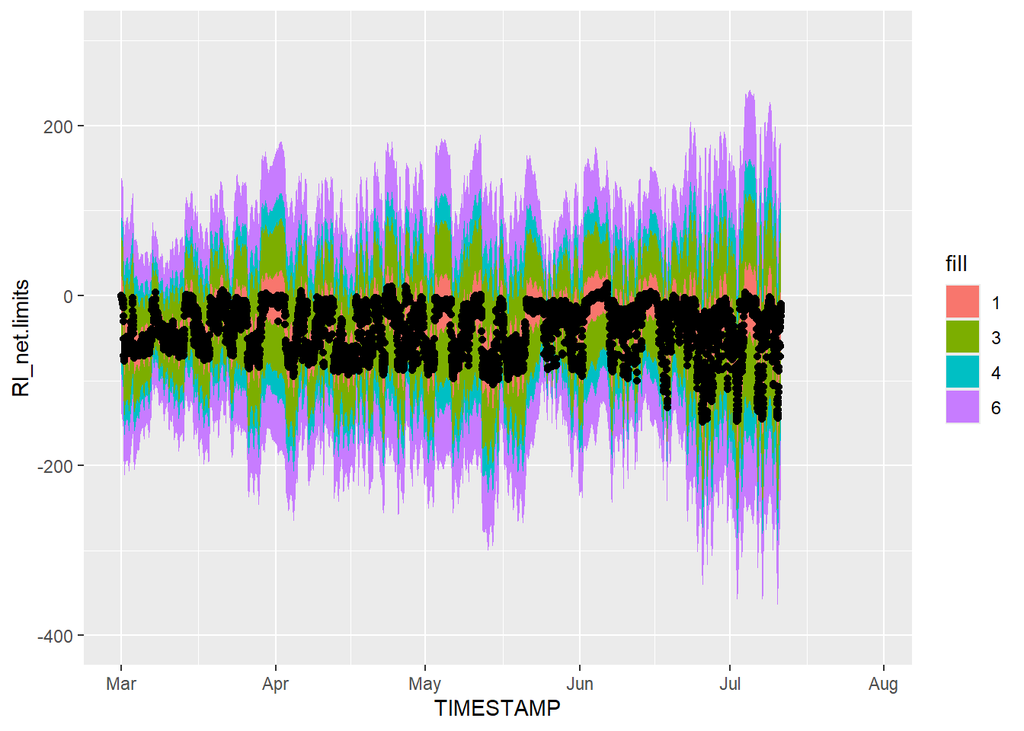

```r
ggplot(data = df)+
  geom_ribbon(aes(x = TIMESTAMP,ymax = mad_filt+roll.mad*6,ymin = mad_filt-roll.mad*6,fill='6'))+
  geom_ribbon(aes(x = TIMESTAMP,ymax = mad_filt+roll.mad*4,ymin = mad_filt-roll.mad*4,fill='4'))+
  geom_ribbon(aes(x = TIMESTAMP,ymax = mad_filt+roll.mad*3,ymin = mad_filt-roll.mad*3,fill='3'))+
  geom_ribbon(aes(x = TIMESTAMP,ymax = mad_filt+roll.mad*1,ymin = mad_filt-roll.mad*1,fill='1'))+
  geom_point(aes(TIMESTAMP,Rl_net.limits),col='red')+
  geom_point(aes(TIMESTAMP,Rl_net_Avg.c),col='black')+
  scale_y_continuous(limits = c(-400, 300))+
  scale_x_datetime(limits = as.POSIXct(biomet_dates,format="%F"))
```

#### Rain

Looks fine, doesn’t do anything

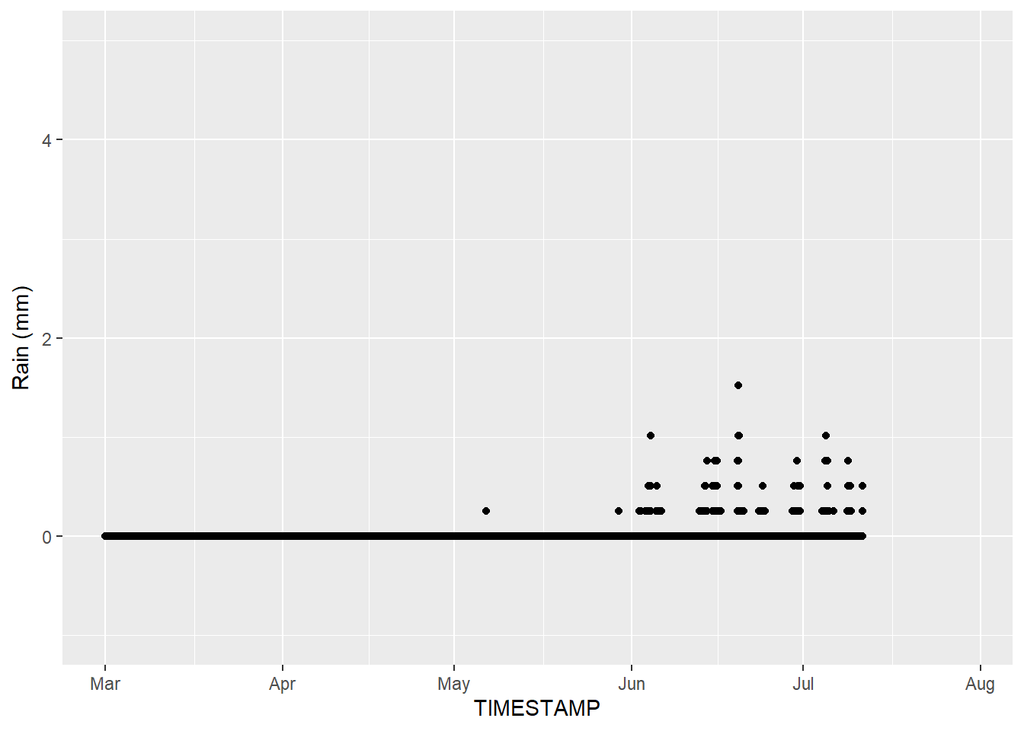

```r
ggplot(data = df)+
  geom_point(aes(TIMESTAMP, Rain_mm_Tot),col='black')+
  scale_y_continuous(limits = c(-1,5),
                     expression('Rain ('*mm*')'))+
  scale_x_datetime(limits = as.POSIXct(biomet_dates,format="%F"))
```

```r
df$Rain_mm_Tot.c = df$Rain_mm_Tot
```

#### Temp 1

Looks fine, doesn’t do anything

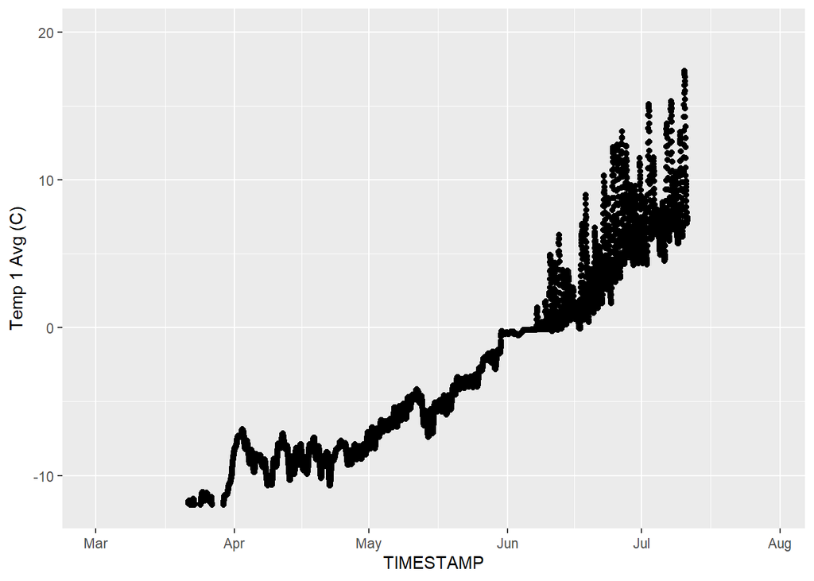

```r
ggplot(data = df)+
  geom_point(aes(TIMESTAMP, Temp_C_Avg_1))+
  scale_y_continuous(limits = c(-12, 20),
                     expression('Temp 1 Avg ('*C*')'))+
  scale_x_datetime(limits = as.POSIXct(biomet_dates,format="%F"))
```

```r
df$Temp_C_Avg_1.c = df$Temp_C_Avg_1
```

#### Temp 2

Looks fine, doesn’t do anything

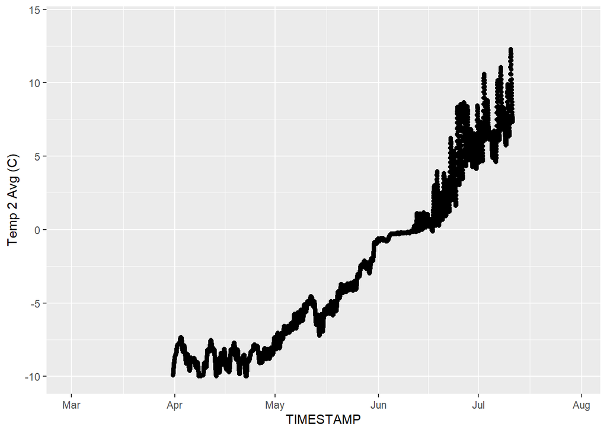

```r
ggplot(data = df)+
  geom_point(aes(TIMESTAMP, Temp_C_Avg_2))+
  scale_y_continuous(limits = c(-10, 14),
                     expression('Temp 2 Avg ('*C*')'))+
  scale_x_datetime(limits = as.POSIXct(biomet_dates,format="%F"))
```

```r
df$Temp_C_Avg_2.c = df$Temp_C_Avg_2
```

#### Temp 3

Looks fine, doesn’t do anything

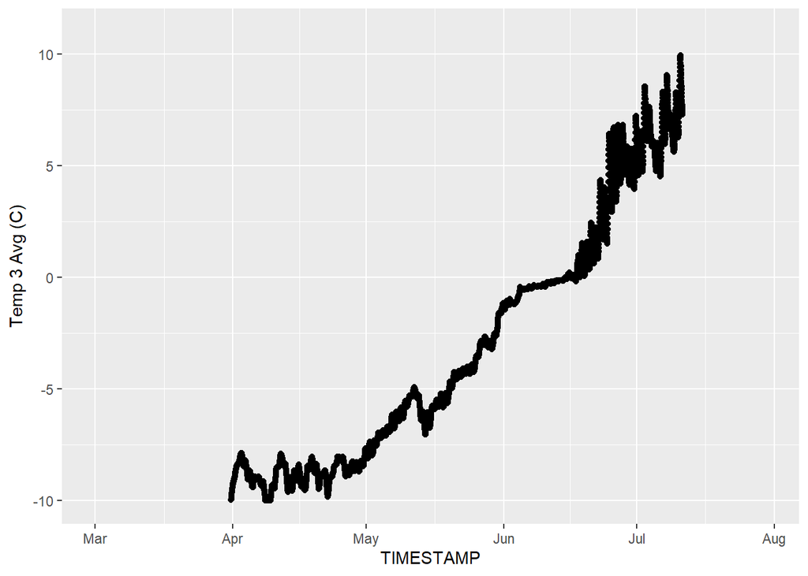

```r
ggplot(data = df)+
  geom_point(aes(TIMESTAMP, Temp_C_Avg_3))+
  scale_y_continuous(limits = c(-10, 11),
                     expression('Temp 3 Avg ('*C*')'))+
  scale_x_datetime(limits = as.POSIXct(biomet_dates,format="%F"))
```

```r
df$Temp_C_Avg_3.c = df$Temp_C_Avg_3
```

#### Temp 4

Looks fine, doesn’t do anything

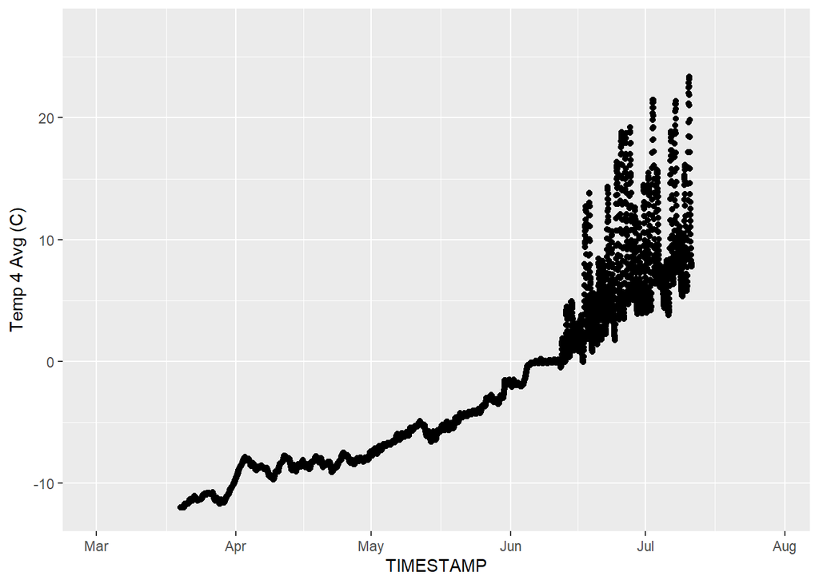

```r
ggplot(data = df)+
  geom_point(aes(TIMESTAMP, Temp_C_Avg_4))+
  scale_y_continuous(limits = c(-12, 27),
                     expression('Temp 4 Avg ('*C*')'))+
  scale_x_datetime(limits = as.POSIXct(biomet_dates,format="%F"))
```

```r
df$Temp_C_Avg_4.c = df$Temp_C_Avg_4
```

#### Temp 5

Looks fine, doesn’t do anything

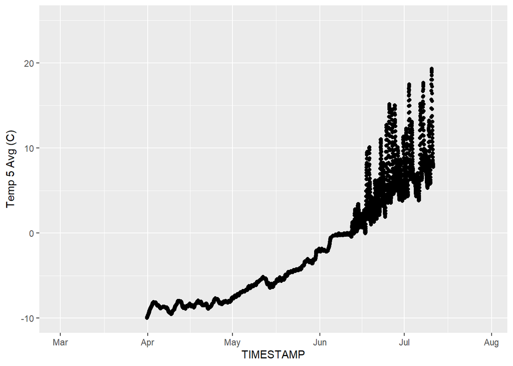

```r
ggplot(data = df)+
  geom_point(aes(TIMESTAMP, Temp_C_Avg_5))+
  scale_y_continuous(limits = c(-10, 25),
                     expression('Temp 5 Avg ('*C*')'))+
  scale_x_datetime(limits = as.POSIXct(biomet_dates,format="%F"))
```

```r
df$Temp_C_Avg_5.c = df$Temp_C_Avg_5
```

#### Temp 6

Cleaning w/ limits

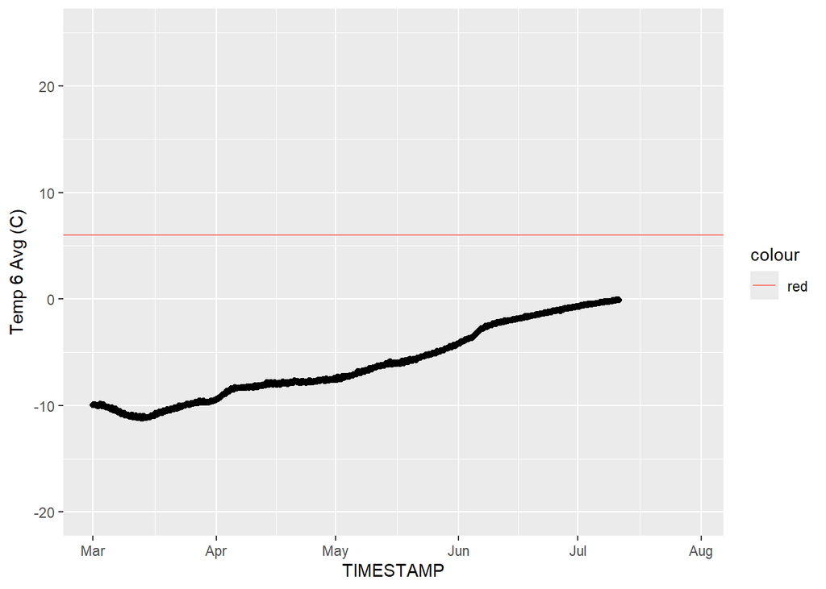

```r
ggplot(data = df)+
  geom_point(aes(TIMESTAMP, Temp_C_Avg_6))+
  geom_hline(aes(yintercept=6, col = 'red'))+
  scale_y_continuous(limits = c(-20,25),
                     expression('Temp 6 Avg ('*C*')'))+
  scale_x_datetime(limits = as.POSIXct(biomet_dates,format="%F"))
```

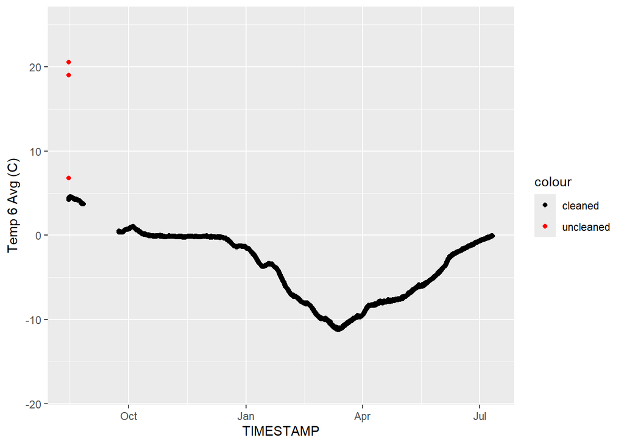

```r
Temp_C_Avg_6.limits = replace(df$Temp_C_Avg_6,df$Temp_C_Avg_6 > 6,NA)

df$Temp_C_Avg_6.c = Temp_C_Avg_6.limits

ggplot(data = df)+
  geom_point(aes(TIMESTAMP, Temp_C_Avg_6, col = 'uncleaned'))+
  geom_point(aes(TIMESTAMP, Temp_C_Avg_6.c, col = 'cleaned'))+
  scale_y_continuous(limits = c(-18,25),
                     expression('Temp 6 Avg ('*C*')'))+scale_color_manual(values=c('black','red'))
```

```r
  scale_x_datetime(limits = as.POSIXct(biomet_dates,format="%F"))
```

```
## <ScaleContinuousDatetime>
##  Range:
##  Limits: 1.71e+09 -- 1.72e+09
```

### Soil meaurements

#### EC columns

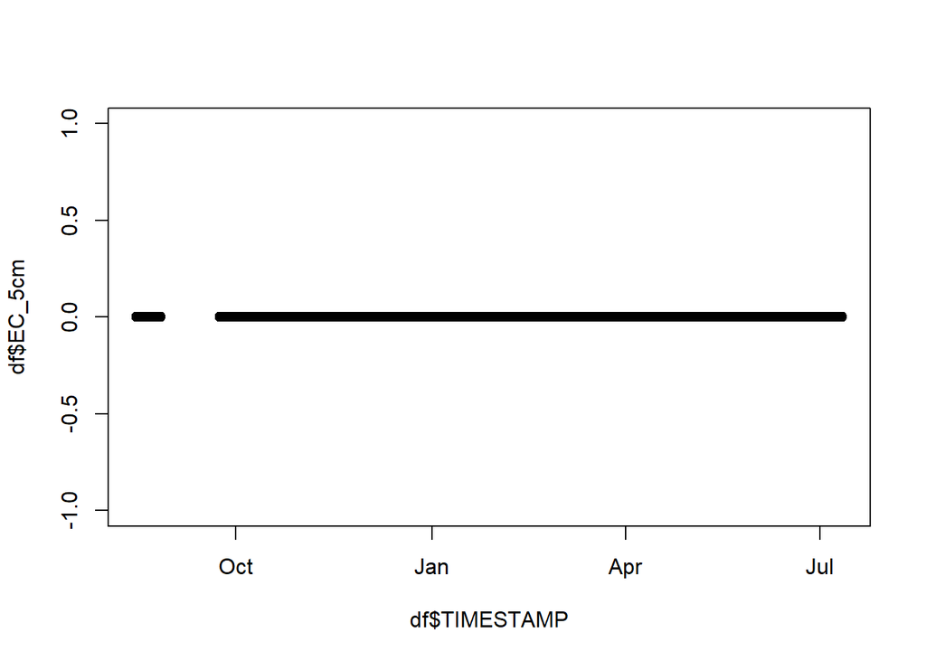

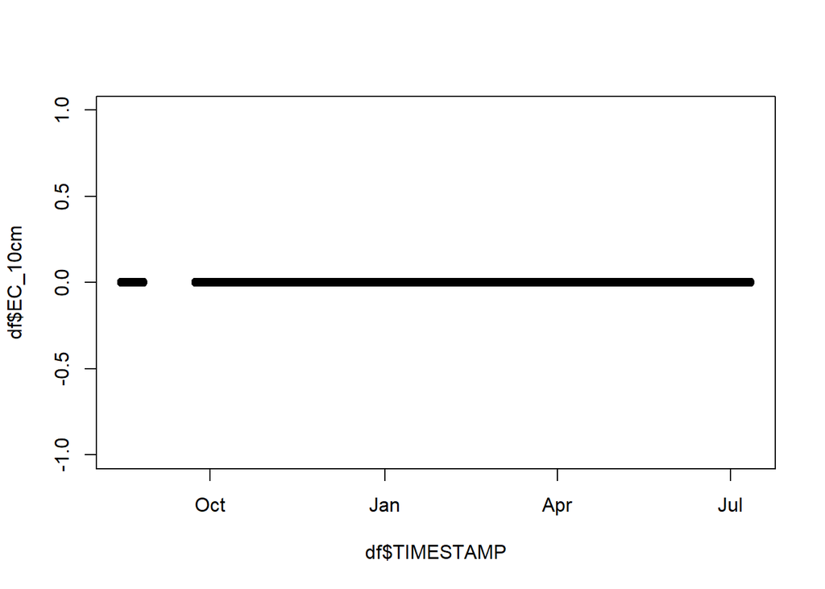

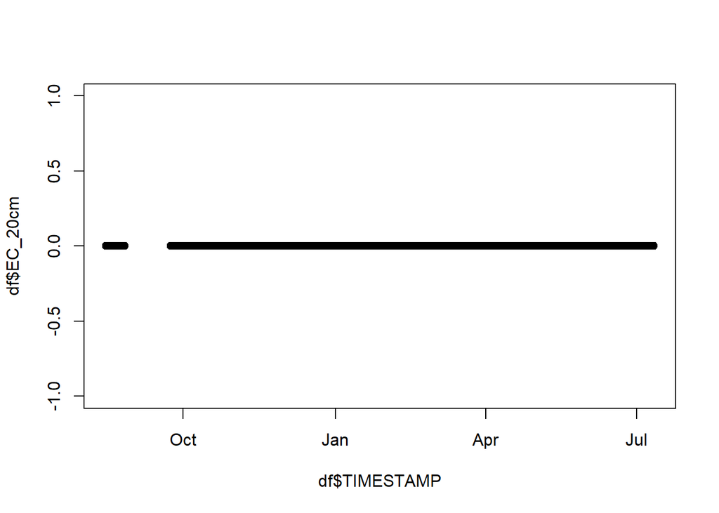

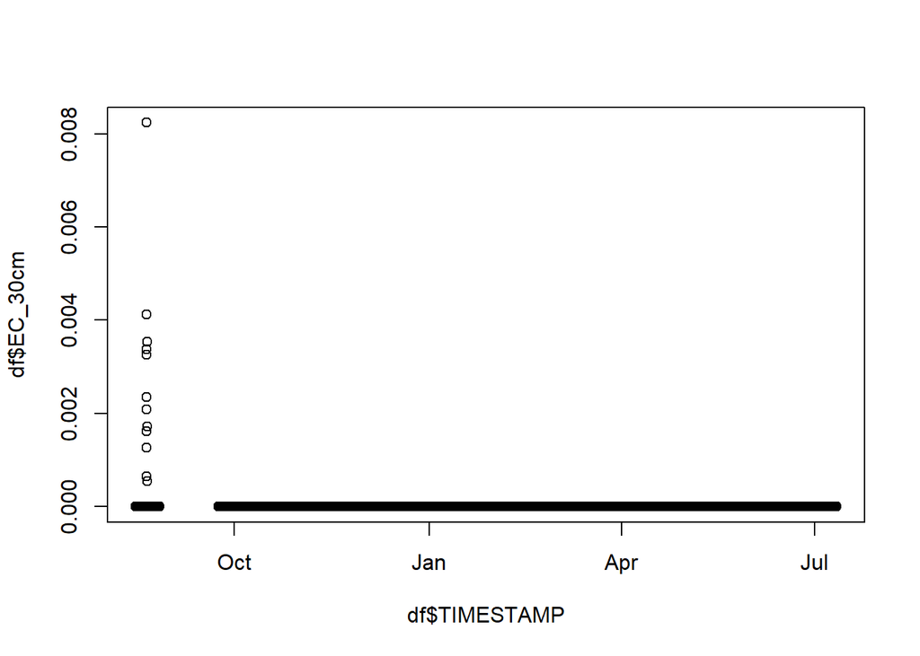

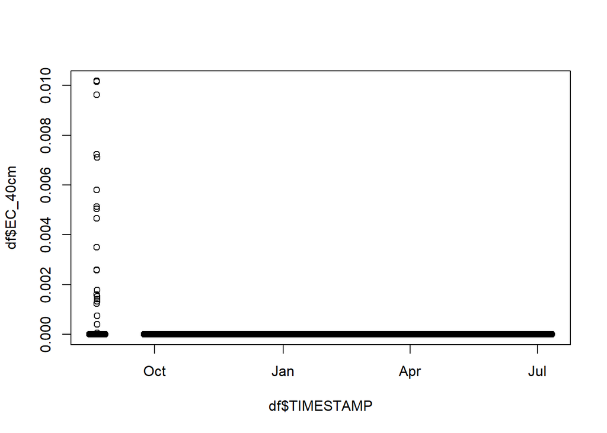

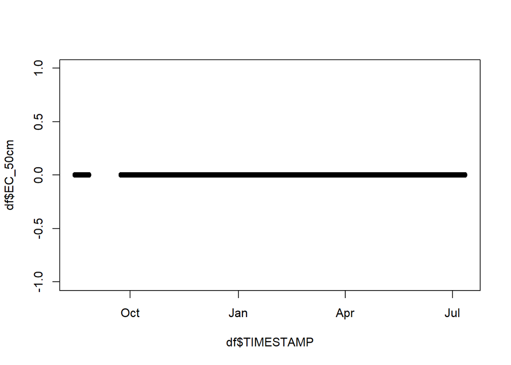

```r
plot_grid(
plot(df$TIMESTAMP, df$EC_5cm),
plot(df$TIMESTAMP, df$EC_10cm),
plot(df$TIMESTAMP, df$EC_20cm),
plot(df$TIMESTAMP, df$EC_30cm),
plot(df$TIMESTAMP, df$EC_40cm),
plot(df$TIMESTAMP, df$EC_50cm)
)
```

#### 5 cm

##### VWC 5cm

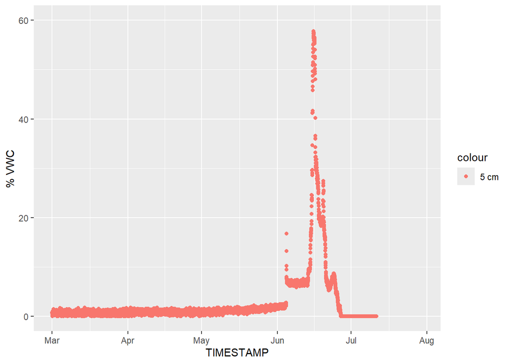

```r
ggplot(data = df)+
  geom_point(aes(TIMESTAMP, VWC_5cm*100,col='5 cm'))+ # convert to percentage
  scale_y_continuous(limits = c(0,60),
                     expression('% VWC'))+
  scale_x_datetime(limits = as.POSIXct(biomet_dates,format="%F"))
```

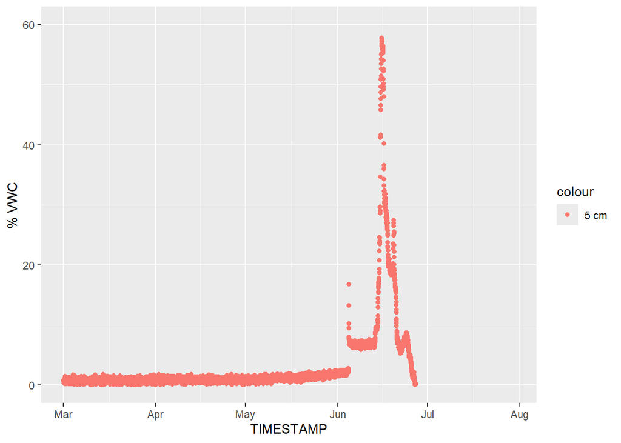

```r
VWC_5cm.limits = df$VWC_5cm

VWC_5cm.limits = ifelse(df$VWC_5cm == 0,NA, VWC_5cm.limits)

df$VWC_5cm.c = VWC_5cm.limits

ggplot(data = df)+
  geom_point(aes(TIMESTAMP, VWC_5cm.c*100,col='5 cm'))+ # convert to percentage
  scale_y_continuous(limits = c(0,60),
                     expression('% VWC'))+
  scale_x_datetime(limits = as.POSIXct(biomet_dates,format="%F"))
```

##### Perm 5cm

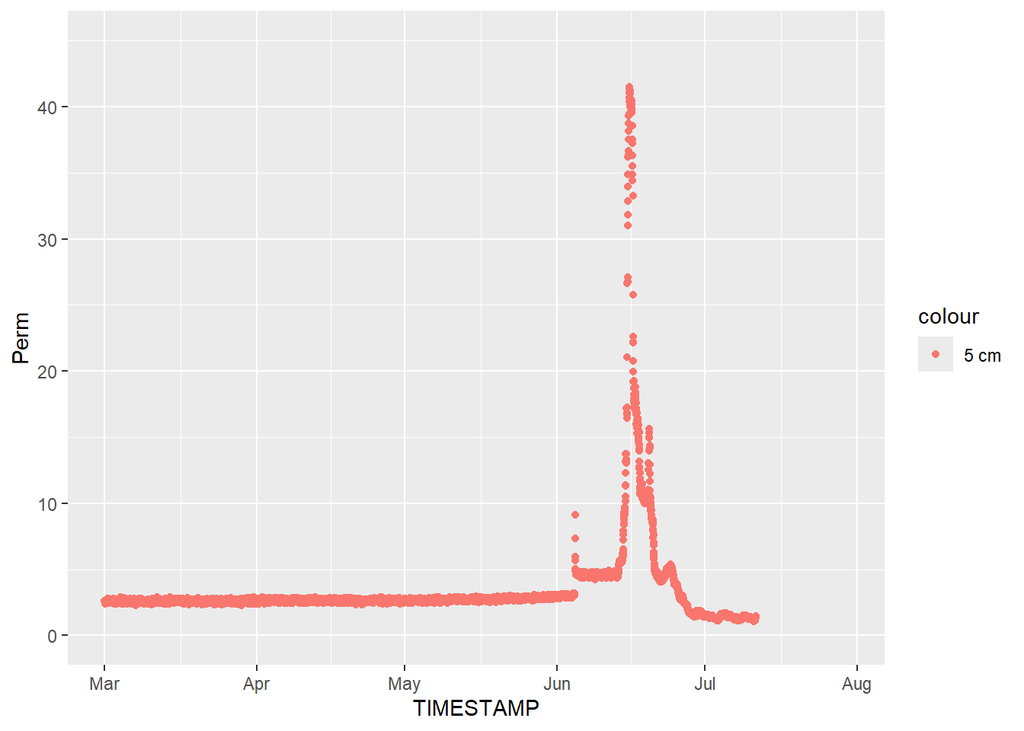

```r
ggplot(data = df)+
  geom_point(aes(TIMESTAMP, Perm_5cm ,col='5 cm'))+
  scale_y_continuous(limits = c(0,45),
                     expression('Perm'))+
  scale_x_datetime(limits = as.POSIXct(biomet_dates,format="%F"))
```

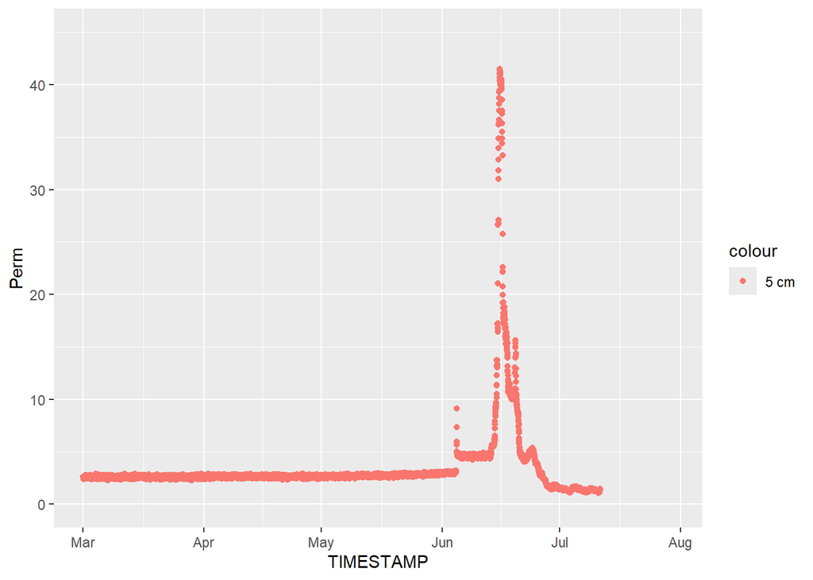

```r
Perm_5cm.limits = df$Perm_5cm

Perm_5cm.limits = ifelse(df$Perm_5cm == 0,NA, Perm_5cm.limits)

df$Perm_5cm.c = Perm_5cm.limits

ggplot(data = df)+
  geom_point(aes(TIMESTAMP, Perm_5cm.c,col='5 cm'))+
  scale_y_continuous(limits = c(0,45),
                     expression('Perm'))+
  scale_x_datetime(limits = as.POSIXct(biomet_dates,format="%F"))
```

Plot perm/VWC w/rain to explain peaks in data

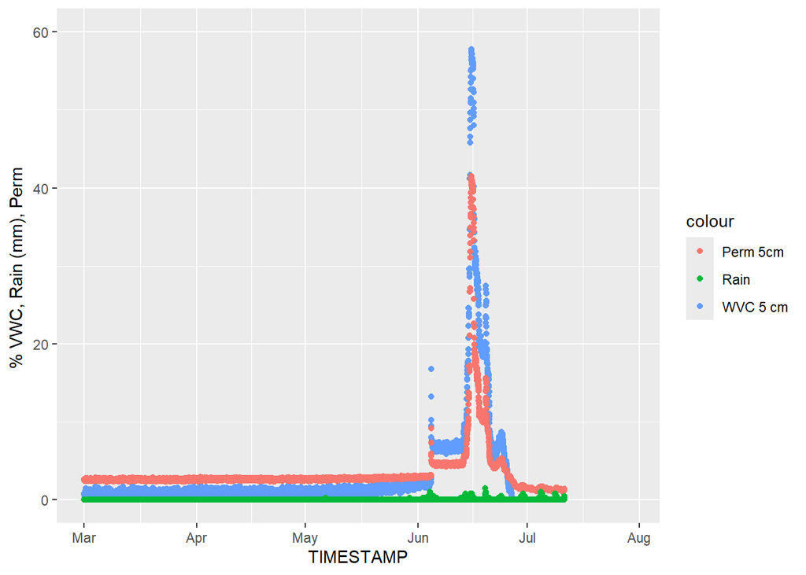

```r
ggplot(data = df)+
  geom_point(aes(TIMESTAMP, VWC_5cm.c*100,col='WVC 5 cm'))+ # convert to percentage
  geom_point(aes(TIMESTAMP, Perm_5cm.c, col='Perm 5cm'))+
  geom_point(aes(TIMESTAMP, Rain_mm_Tot.c, col='Rain'))+
  scale_y_continuous(limits = c(0,60), expression("% VWC, Rain (mm), Perm")) +
  scale_x_datetime(limits = as.POSIXct(biomet_dates,format="%F"))
```

##### Soil temp 5cm

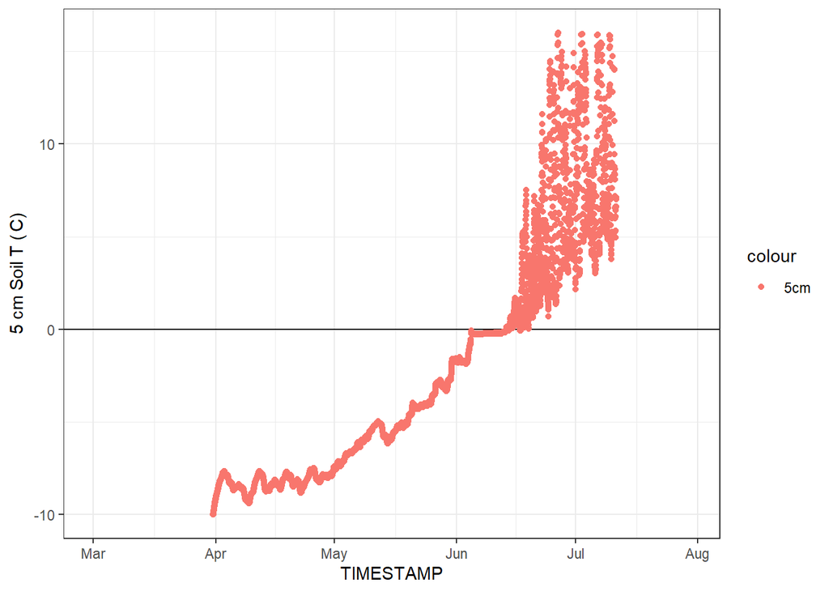

```r
ggplot(data = df)+ theme_bw()+ geom_hline(yintercept = 0)+
  geom_point(aes(TIMESTAMP, TC_5cm, col = '5cm'))+
  scale_y_continuous(limits = c(-10, 16),
                     expression('5 cm Soil T ('*C*')'))+
  scale_x_datetime(limits = as.POSIXct(biomet_dates))
```

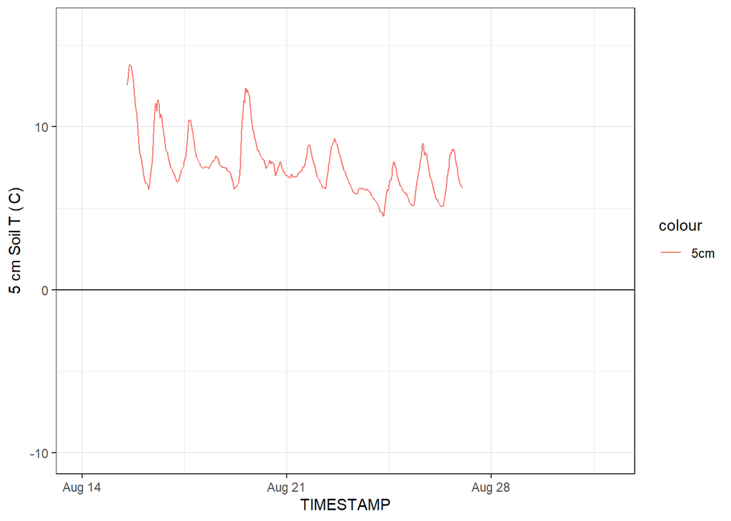

```r
TC_5cm.limits = df$TC_5cm

TC_5cm.limits = ifelse(df$TC_5cm == 0 & df$TIMESTAMP >= '2023-08-14' & df$TIMESTAMP <= '2023-09-01' ,NA, TC_5cm.limits)

## Check to see values are removed
ggplot(data = df)+ theme_bw()+ geom_hline(yintercept = 0)+
  geom_line(aes(TIMESTAMP, TC_5cm.limits, col = '5cm'))+
  scale_y_continuous(limits = c(-10, 16),
                     expression('5 cm Soil T ('*C*')'))+
  scale_x_datetime(limits = as.POSIXct(c('2023-08-14','2023-09-01')))
```

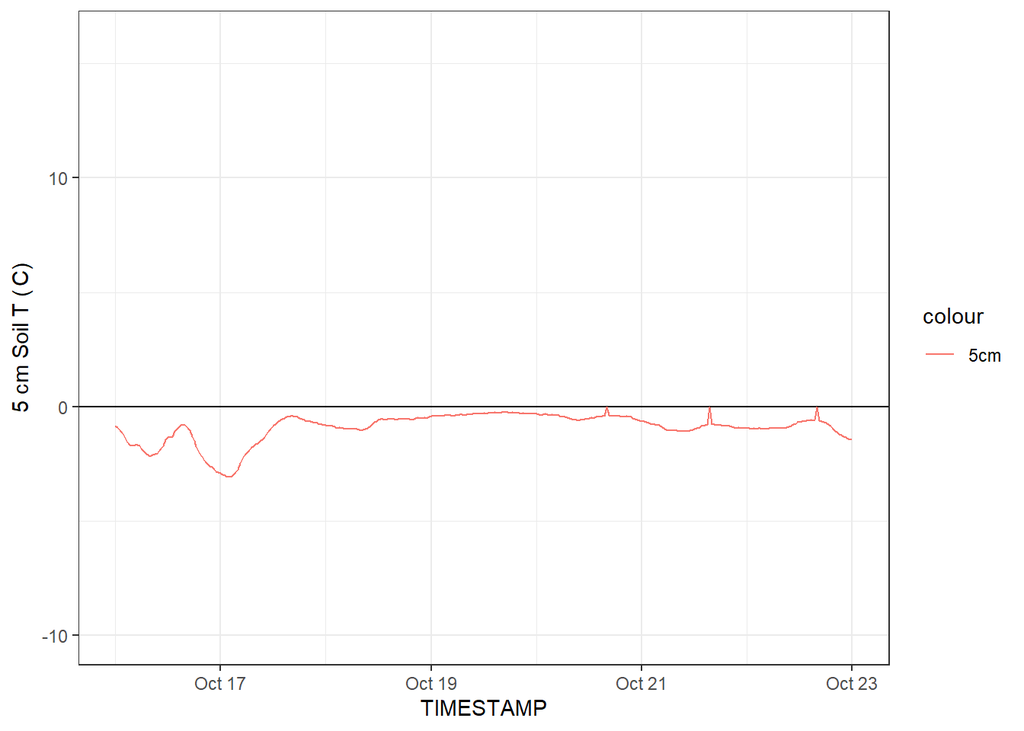

```r
ggplot(data = df)+ theme_bw()+ geom_hline(yintercept = 0)+
  geom_line(aes(TIMESTAMP, TC_5cm, col = '5cm'))+
  scale_y_continuous(limits = c(-10, 16),
                     expression('5 cm Soil T ('*C*')'))+
  scale_x_datetime(limits = as.POSIXct(c('2023-10-16', '2023-10-23')))
```

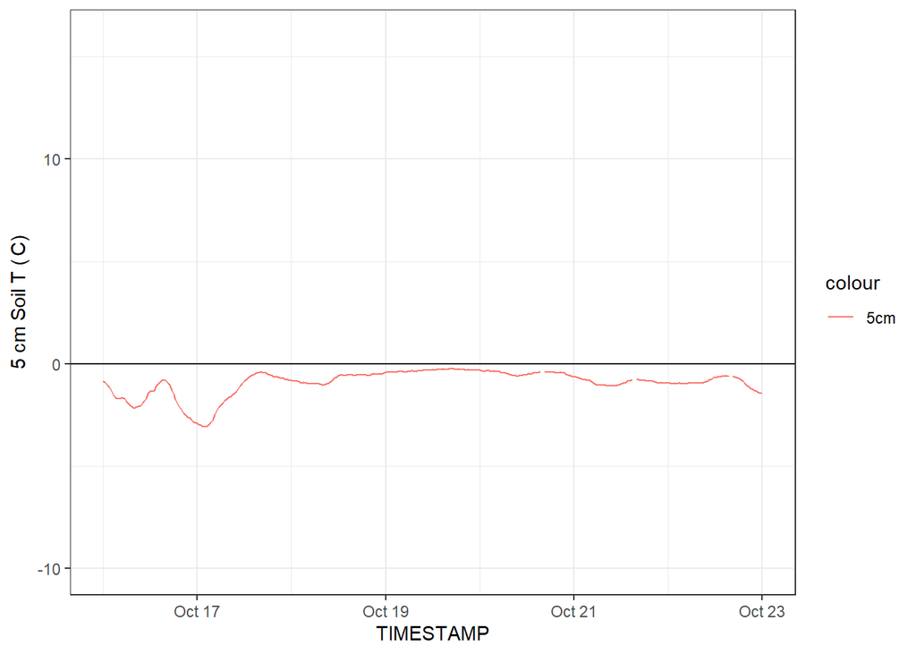

```r
TC_5cm.limits = ifelse(df$TC_5cm == 0 & df$TIMESTAMP >= '2023-10-16' & df$TIMESTAMP <= '2023-10-23' ,NA, TC_5cm.limits)

## Check to see values are removed
ggplot(data = df)+ theme_bw()+ geom_hline(yintercept = 0)+
  geom_line(aes(TIMESTAMP, TC_5cm.limits, col = '5cm'))+
  scale_y_continuous(limits = c(-10, 16),
                     expression('5 cm Soil T ('*C*')'))+
  scale_x_datetime(limits = as.POSIXct(c('2023-10-16', '2023-10-23')))
```

Rolling MAD

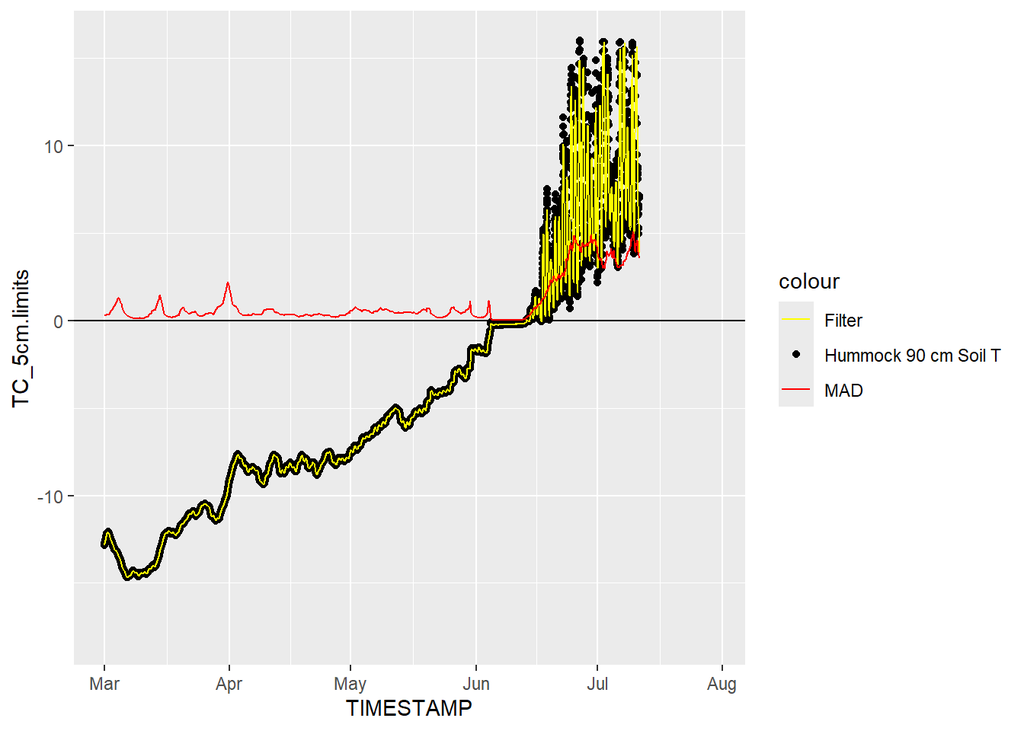

```r
f = TC_5cm.limits # first make a new flux vector to apply the above filters
# prepare the inputs for a zero-phase (forward and reverse) filter
ind       = which(complete.cases(f))   # first save the index of all the NAs
b         = rep(1,8)/8                 # moving average coefficient
a         = 1                          # coefficient of the ARMA filter
mad_i    = filtfilt(b, a, na.omit(f)) #create a forward and reverse ARMA filter
mad_filt = f                          # make a copy of the full fluxes again
mad_filt[ind] = mad_i                # apply the filter where the real data exist

n = 7*48 # set the length of the rolling filter, 48 half hours in day * x days
roll.mad = rollapply(data = mad_filt,
                     width = n,
                     FUN = mad,
                     partial = TRUE,
                     na.rm = T,
                     fill = NA)  #create a rolling MAD or sd or other
roll.mad[is.na(mad_filt)] = NA  #make NA values where NAs exist in the real data

ggplot(df)+geom_hline(yintercept = 0)+
  geom_point(aes(TIMESTAMP,TC_5cm.limits,col='Hummock 90 cm Soil T'))+
  geom_line(aes(TIMESTAMP,mad_filt,col='Filter'))+
  geom_line(aes(TIMESTAMP,roll.mad,col='MAD'))+
  scale_y_continuous(limits = c(-18,16))+
  scale_x_datetime(limits = as.POSIXct(biomet_dates,format="%F"))+
  scale_color_manual(values=c('yellow','black','red'))
```

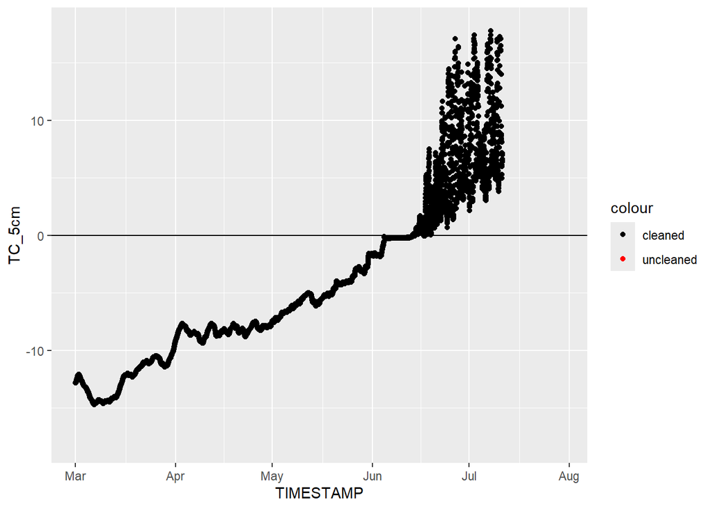

```r
#adjust this value (N) to tweak how many MADs to be away from the norm
N = 3

#Add clean value to dataframe (_.c)

df$TC_5cm.c = ifelse(abs(TC_5cm.limits - mad_filt) > (N * roll.mad),NA,TC_5cm.limits)

#Compare cleaned vs. uncleaned

ggplot(data = df)+geom_hline(yintercept = 0)+
  geom_point(aes(TIMESTAMP,TC_5cm,col='uncleaned'))+
  geom_point(aes(TIMESTAMP,TC_5cm.c,col='cleaned'))+
  scale_y_continuous(limits=c(-18,18))+
  scale_x_datetime(limits = as.POSIXct(biomet_dates,format="%F"))+
  scale_color_manual(values=c('black','red'))
```

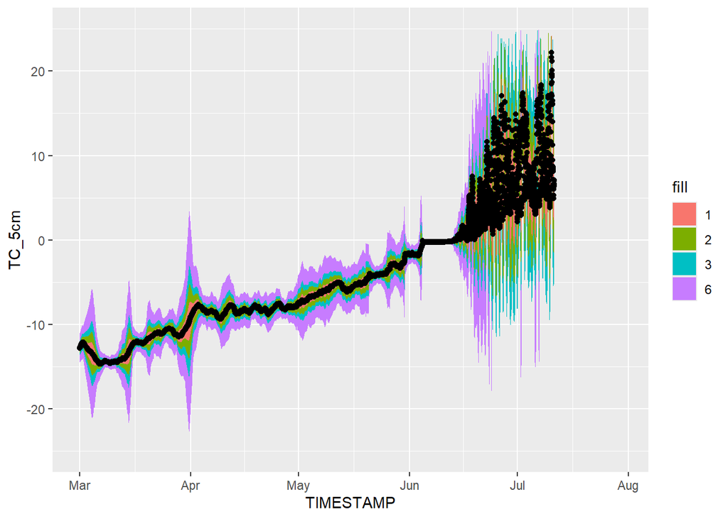

```r
ggplot(data = df)+
  geom_ribbon(aes(x = TIMESTAMP,ymax = mad_filt+roll.mad*6,ymin = mad_filt-roll.mad*6,fill='6'))+
  geom_ribbon(aes(x = TIMESTAMP,ymax = mad_filt+roll.mad*3,ymin = mad_filt-roll.mad*3,fill='3'))+
  geom_ribbon(aes(x = TIMESTAMP,ymax = mad_filt+roll.mad*2,ymin = mad_filt-roll.mad*2,fill='2'))+
  geom_ribbon(aes(x = TIMESTAMP,ymax = mad_filt+roll.mad*1,ymin = mad_filt-roll.mad*1,fill='1'))+
  geom_point(aes(TIMESTAMP,TC_5cm),col='red')+
  geom_point(aes(TIMESTAMP,TC_5cm.c),col='black')+
  scale_y_continuous(limits = c(-25,25))+
  scale_x_datetime(limits = as.POSIXct(biomet_dates,format="%F"))
```

#### 10 cm

##### VWC 10cm

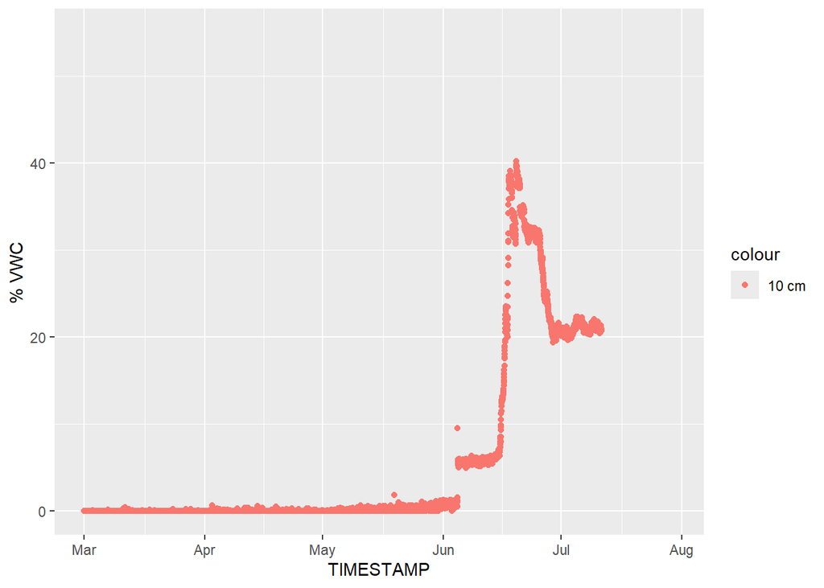

```r
ggplot(data = df)+
  geom_point(aes(TIMESTAMP, VWC_10cm*100,col='10 cm'))+ # convert to percentage
  scale_y_continuous(limits = c(0,55),
                     expression('% VWC'))+
  scale_x_datetime(limits = as.POSIXct(biomet_dates,format="%F"))
```

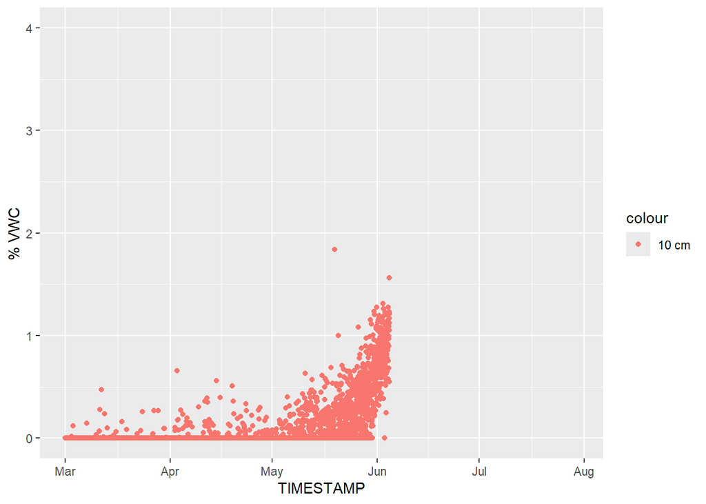

```r
ggplot(data = df)+
  geom_point(aes(TIMESTAMP, VWC_10cm*100,col='10 cm'))+
  scale_y_continuous(limits = c(0,4),
                     expression('% VWC'))+
  scale_x_datetime(limits = as.POSIXct(biomet_dates))
```

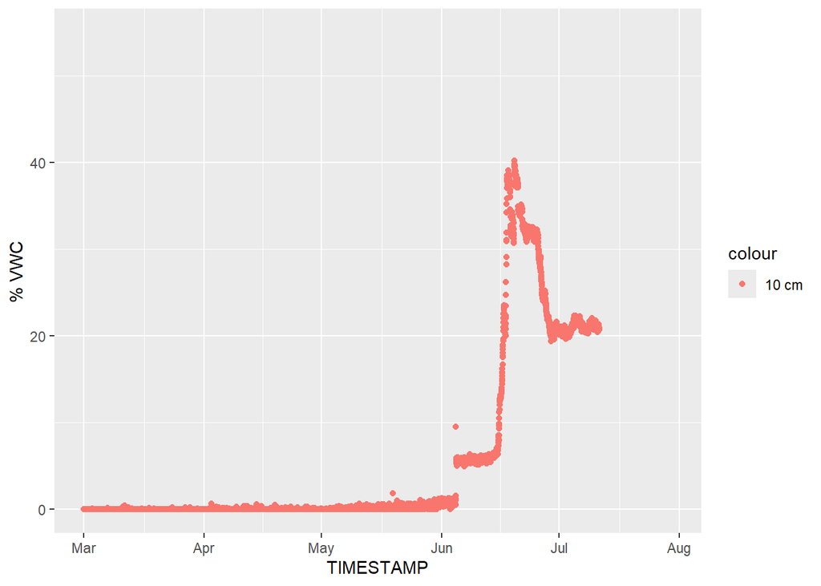

```r
VWC_10cm.limits = df$VWC_10cm

VWC_10cm.limits = ifelse(df$VWC_10cm == 0 & df$TIMESTAMP <= '2023-10-24' ,NA, VWC_10cm.limits)

df$VWC_10cm.c = VWC_10cm.limits

# Check to see if values are removed

ggplot(data = df)+
  geom_point(aes(TIMESTAMP, VWC_10cm.c*100,col='10 cm'))+ # convert to percentage
  scale_y_continuous(limits = c(0,55),
                     expression('% VWC'))+
  scale_x_datetime(limits = as.POSIXct(biomet_dates,format="%F"))
```

##### Perm 10cm

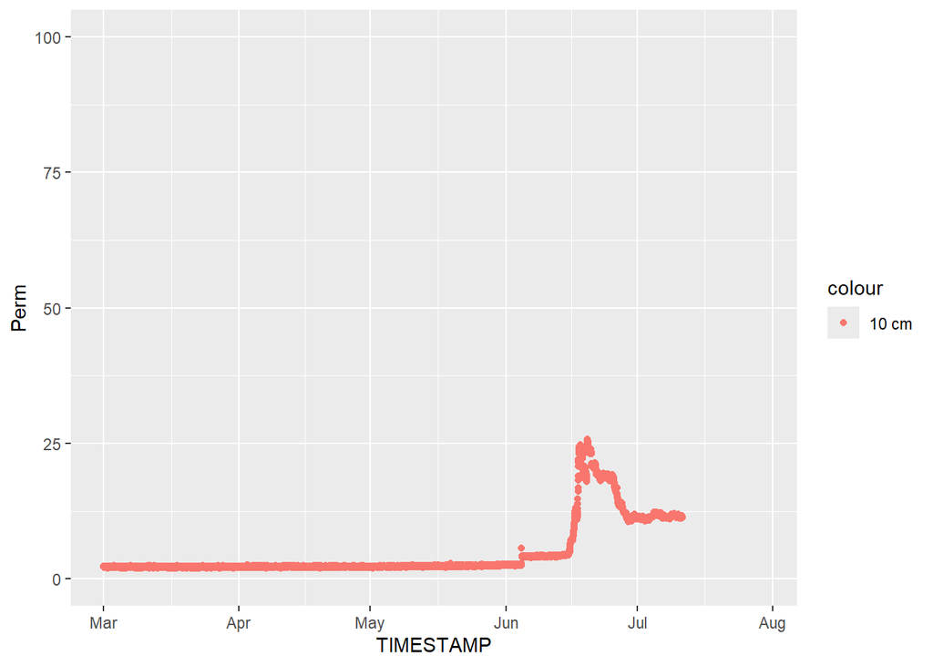

```r
ggplot(data = df)+
  geom_point(aes(TIMESTAMP, Perm_10cm ,col='10 cm'))+
  scale_y_continuous(limits = c(0,100),
                     expression('Perm'))+
  scale_x_datetime(limits = as.POSIXct(biomet_dates,format="%F"))
```

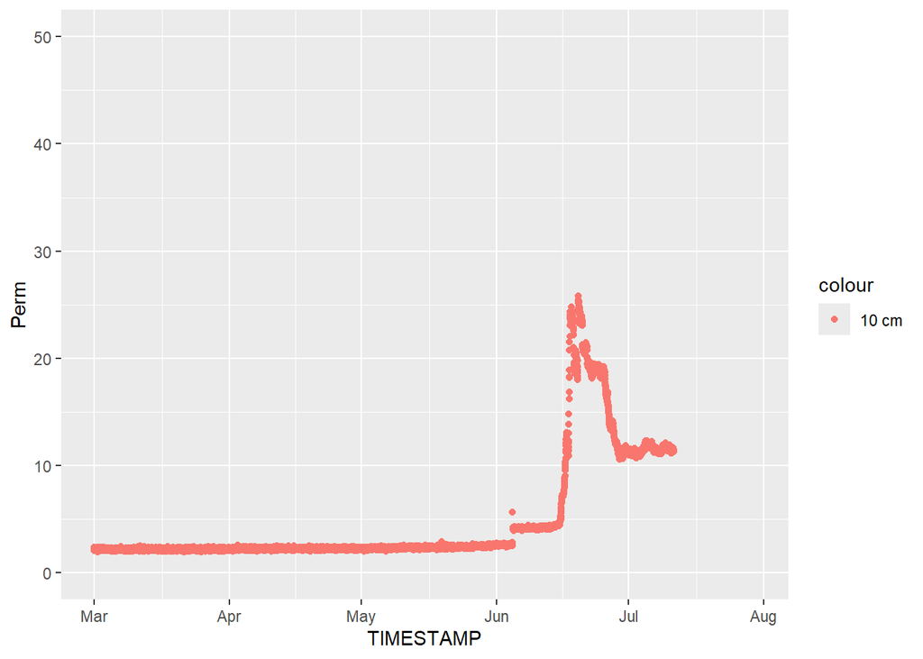

```r
Perm_10cm.limits = df$Perm_10cm

Perm_10cm.limits = ifelse(df$Perm_10cm == 0 & df$TIMESTAMP <= '2023-10-24' ,NA, Perm_10cm.limits)

df$Perm_10cm.c = Perm_10cm.limits

ggplot(data = df)+
  geom_point(aes(TIMESTAMP, Perm_10cm.c,col='10 cm'))+
  scale_y_continuous(limits = c(0,50),
                     expression('Perm'))+
  scale_x_datetime(limits = as.POSIXct(biomet_dates,format="%F"))
```

##### Soil temp 10cm

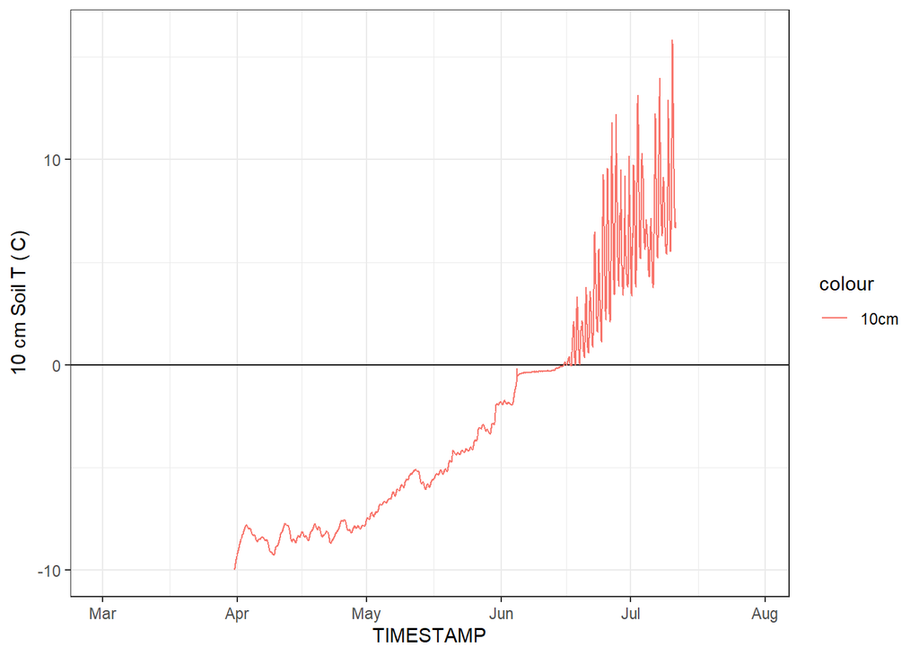

```r
ggplot(data = df)+ theme_bw()+ geom_hline(yintercept = 0)+
  geom_line(aes(TIMESTAMP, TC_10cm, col = '10cm'))+
  scale_y_continuous(limits = c(-10,16),
                     expression('10 cm Soil T ('*C*')'))+
  scale_x_datetime(limits = as.POSIXct(biomet_dates,format="%F"))
```

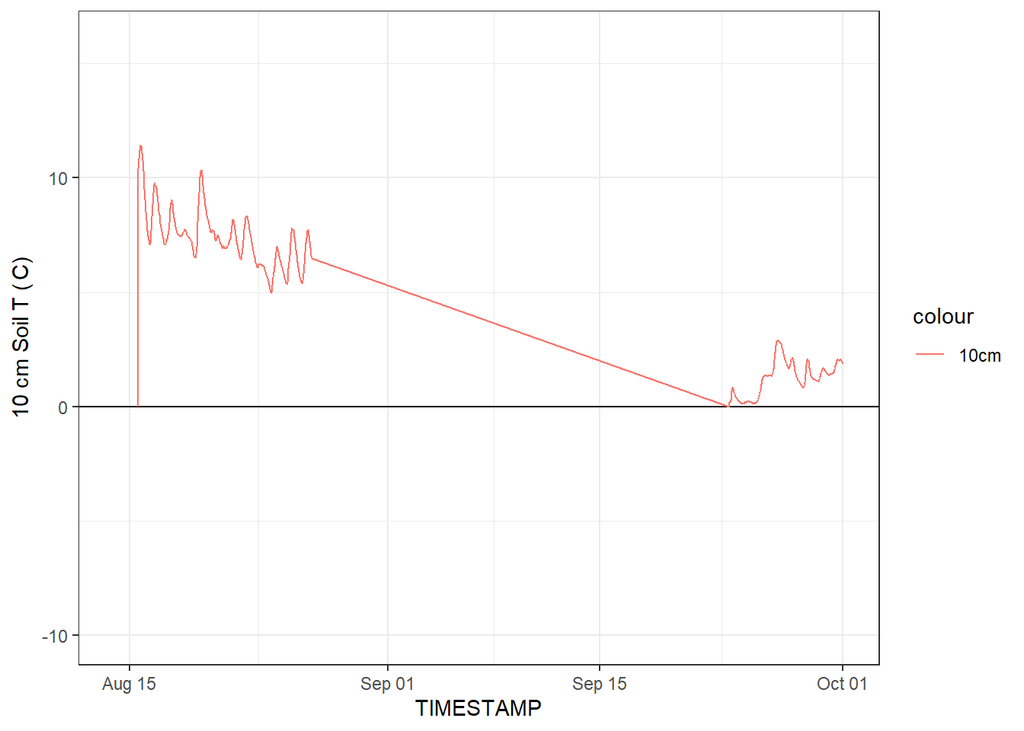

```r
TC_10cm.limits = df$TC_10cm


## Limits- removes a few zeros

# Removes early zeros
ggplot(data = df)+ theme_bw()+ geom_hline(yintercept = 0)+
  geom_line(aes(TIMESTAMP, TC_10cm, col = '10cm'))+
  scale_y_continuous(limits = c(-10, 16),
                     expression('10 cm Soil T ('*C*')'))+
  scale_x_datetime(limits = as.POSIXct(c('2023-08-14','2023-10-01')))
```

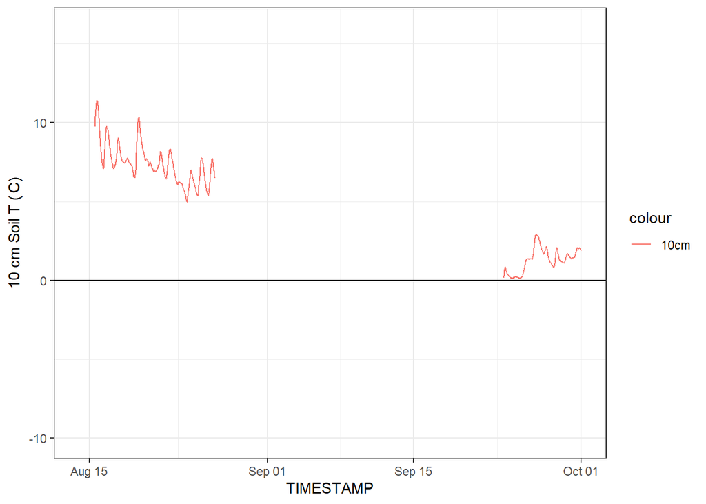

```r
TC_10cm.limits = ifelse(df$TC_10cm == 0 & df$TIMESTAMP <= '2023-10-01' ,NA, TC_10cm.limits)

# Check to see values are removed
ggplot(data = df)+ theme_bw()+ geom_hline(yintercept = 0)+
  geom_line(aes(TIMESTAMP, TC_10cm.limits, col = '10cm'))+
  scale_y_continuous(limits = c(-10, 16),
                     expression('10 cm Soil T ('*C*')'))+
  scale_x_datetime(limits = as.POSIXct(c('2023-08-14','2023-10-01')))
```

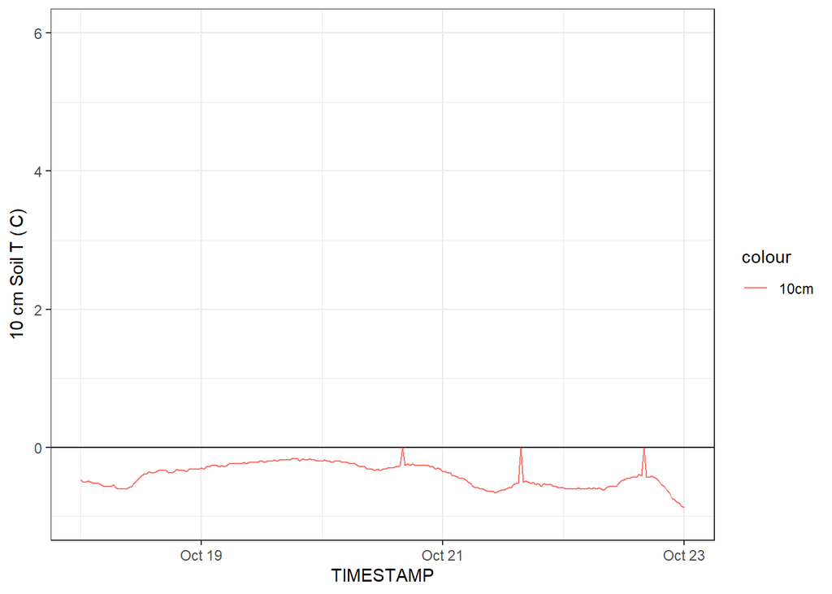

```r
# finds & removes later zeroes
ggplot(data = df)+ theme_bw()+ geom_hline(yintercept = 0)+
  geom_line(aes(TIMESTAMP, TC_10cm, col = '10cm'))+
  scale_y_continuous(limits = c(-1, 6),
                     expression('10 cm Soil T ('*C*')'))+
  scale_x_datetime(limits = as.POSIXct(c('2023-10-18', '2023-10-23')))
```

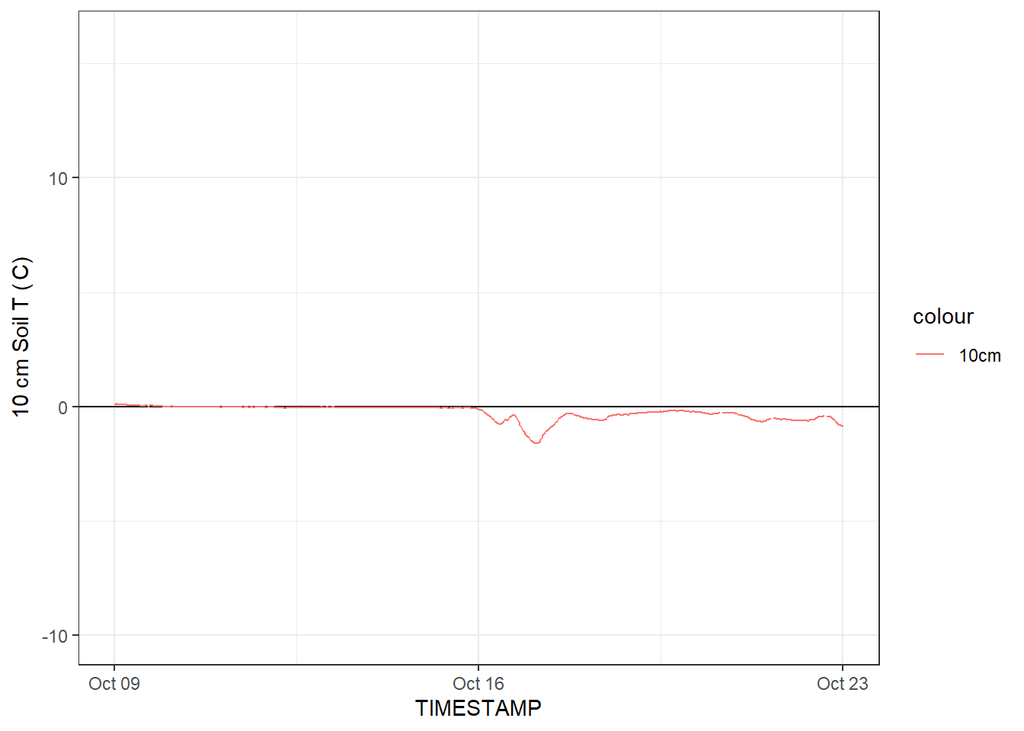

```r
TC_10cm.limits = ifelse(df$TC_10cm == 0 & df$TIMESTAMP >= '2023-10-18' & df$TIMESTAMP <= '2023-10-23' ,NA, TC_10cm.limits)

# Check to see values are removed
ggplot(data = df)+ theme_bw()+ geom_hline(yintercept = 0)+
  geom_line(aes(TIMESTAMP, TC_10cm.limits, col = '10cm'))+
  scale_y_continuous(limits = c(-10, 16),
                     expression('10 cm Soil T ('*C*')'))+
  scale_x_datetime(limits = as.POSIXct(c('2023-10-09', '2023-10-23')))
```

Rolling MAD

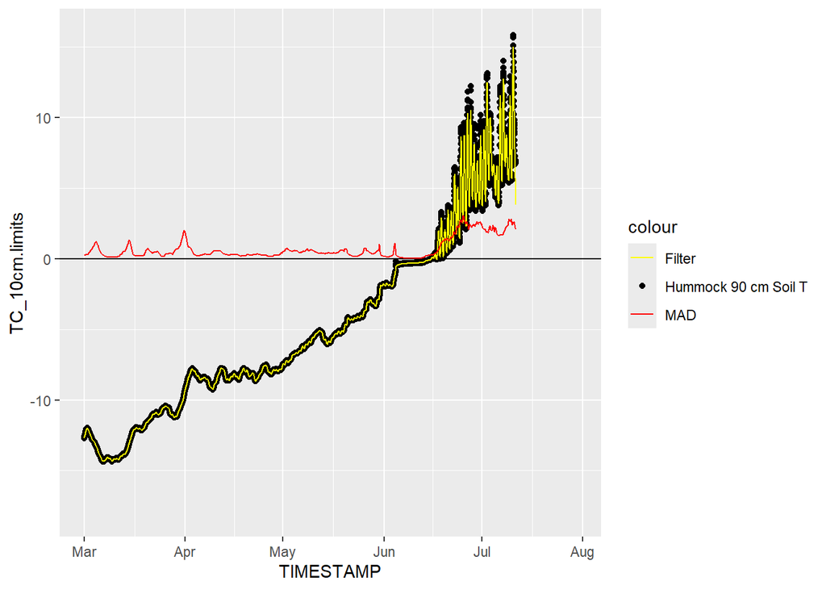

```r
f = TC_10cm.limits # first make a new flux vector to apply the above filters
# prepare the inputs for a zero-phase (forward and reverse) filter
ind       = which(complete.cases(f))   # first save the index of all the NAs
b         = rep(1,8)/8                 # moving average coefficient
a         = 1                          # coefficient of the ARMA filter
mad_i    = filtfilt(b, a, na.omit(f)) #create a forward and reverse ARMA filter
mad_filt = f                          # make a copy of the full fluxes again
mad_filt[ind] = mad_i                # apply the filter where the real data exist

n = 7*48 # set the length of the rolling filter, 48 half hours in day * x days
roll.mad = rollapply(data = mad_filt,
                     width = n,
                     FUN = mad,
                     partial = TRUE,
                     na.rm = T,
                     fill = NA)  #create a rolling MAD or sd or other
roll.mad[is.na(mad_filt)] = NA  #make NA values where NAs exist in the real data

ggplot(df)+geom_hline(yintercept = 0)+
  geom_point(aes(TIMESTAMP,TC_10cm.limits,col='Hummock 90 cm Soil T'))+
  geom_line(aes(TIMESTAMP,mad_filt,col='Filter'))+
  geom_line(aes(TIMESTAMP,roll.mad,col='MAD'))+
  scale_y_continuous(limits = c(-18,16))+
  scale_x_datetime(limits = as.POSIXct(biomet_dates,format="%F"))+
  scale_color_manual(values=c('yellow','black','red'))
```

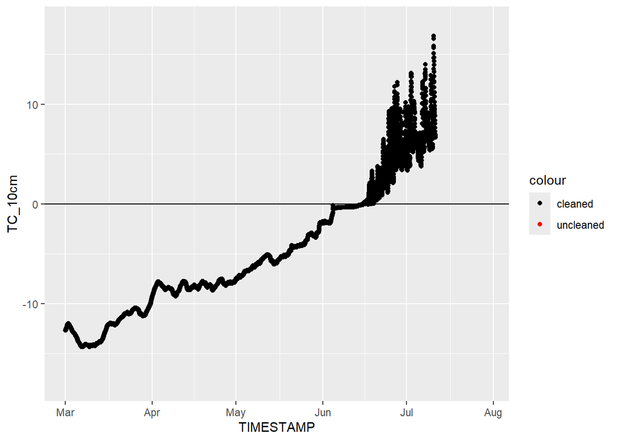

```r
#adjust this value (N) to tweak how many MADs to be away from the norm
N = 6

#Add clean value to dataframe (_.c)

df$TC_10cm.c = ifelse(abs(TC_10cm.limits - mad_filt) > (N * roll.mad),NA,TC_10cm.limits)

#Compare cleaned vs. uncleaned

ggplot(data = df)+geom_hline(yintercept = 0)+
  geom_point(aes(TIMESTAMP,TC_10cm,col='uncleaned'))+
  geom_point(aes(TIMESTAMP,TC_10cm.c,col='cleaned'))+
  scale_y_continuous(limits=c(-18,18))+
  scale_x_datetime(limits = as.POSIXct(biomet_dates,format="%F"))+
  scale_color_manual(values=c('black','red'))
```

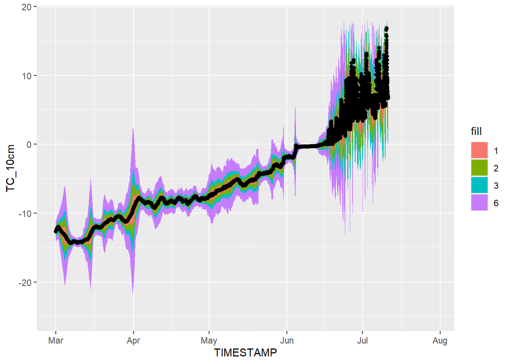

```r
ggplot(data = df)+
  geom_ribbon(aes(x = TIMESTAMP,ymax = mad_filt+roll.mad*6,ymin = mad_filt-roll.mad*6,fill='6'))+
  geom_ribbon(aes(x = TIMESTAMP,ymax = mad_filt+roll.mad*3,ymin = mad_filt-roll.mad*3,fill='3'))+
  geom_ribbon(aes(x = TIMESTAMP,ymax = mad_filt+roll.mad*2,ymin = mad_filt-roll.mad*2,fill='2'))+
  geom_ribbon(aes(x = TIMESTAMP,ymax = mad_filt+roll.mad*1,ymin = mad_filt-roll.mad*1,fill='1'))+
  geom_point(aes(TIMESTAMP,TC_10cm),col='red')+
  geom_point(aes(TIMESTAMP,TC_10cm.c),col='black')+
  scale_y_continuous(limits = c(-25,18))+
  scale_x_datetime(limits = as.POSIXct(biomet_dates,format="%F"))
```

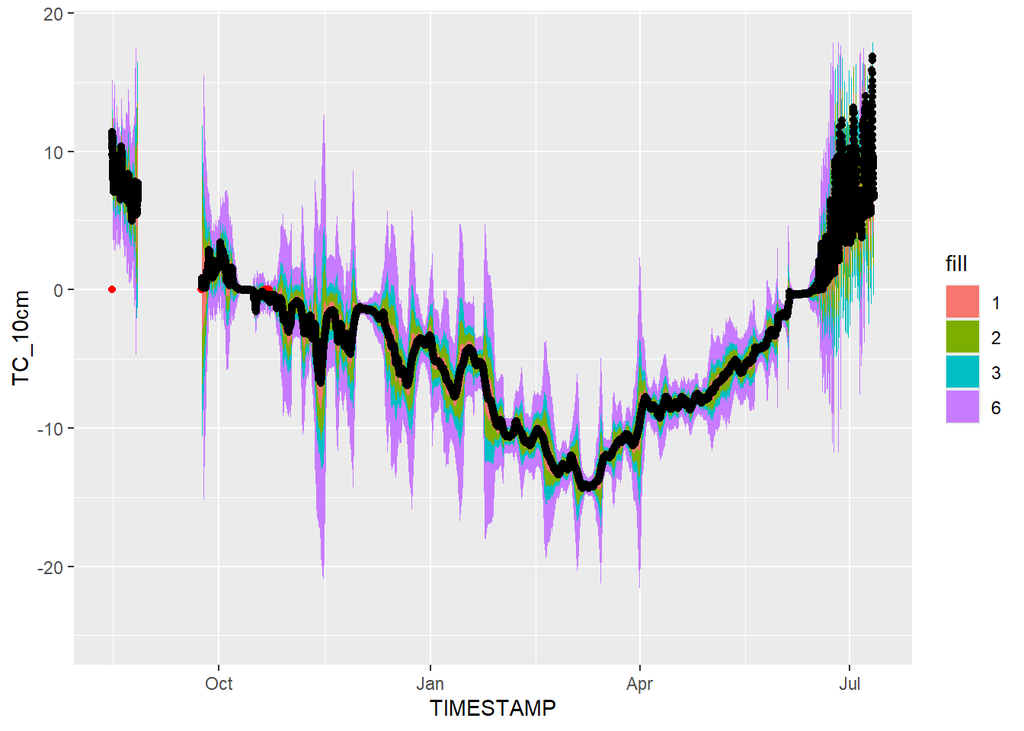

```r
# plot showing zeros getting removed by rolling MAD
ggplot(data = df)+
  geom_ribbon(aes(x = TIMESTAMP,ymax = mad_filt+roll.mad*6,ymin = mad_filt-roll.mad*6,fill='6'))+
  geom_ribbon(aes(x = TIMESTAMP,ymax = mad_filt+roll.mad*3,ymin = mad_filt-roll.mad*3,fill='3'))+
  geom_ribbon(aes(x = TIMESTAMP,ymax = mad_filt+roll.mad*2,ymin = mad_filt-roll.mad*2,fill='2'))+
  geom_ribbon(aes(x = TIMESTAMP,ymax = mad_filt+roll.mad*1,ymin = mad_filt-roll.mad*1,fill='1'))+
  geom_point(aes(TIMESTAMP,TC_10cm),col='red')+
  geom_point(aes(TIMESTAMP,TC_10cm.c),col='black')+
  scale_y_continuous(limits = c(-25,18))
```

#### 20 cm

##### VWC 20cm

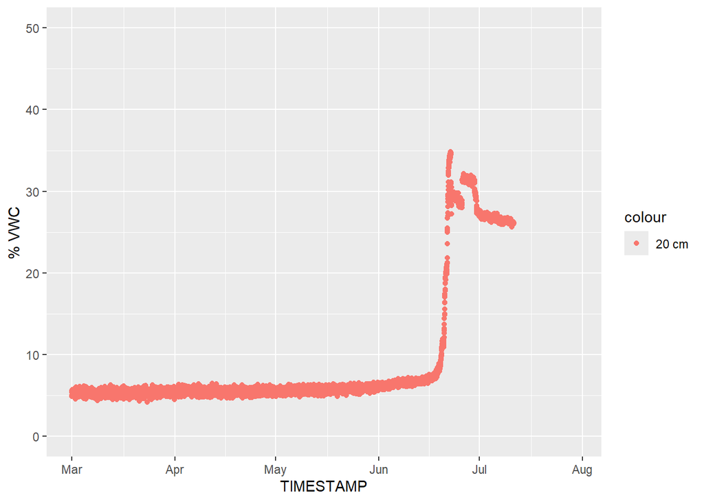

```r
ggplot(data = df)+
  geom_point(aes(TIMESTAMP, VWC_20cm*100,col='20 cm'))+ # convert to percentage
  scale_y_continuous(limits = c(0,50),
                     expression('% VWC'))+
  scale_x_datetime(limits = as.POSIXct(biomet_dates,format="%F"))
```

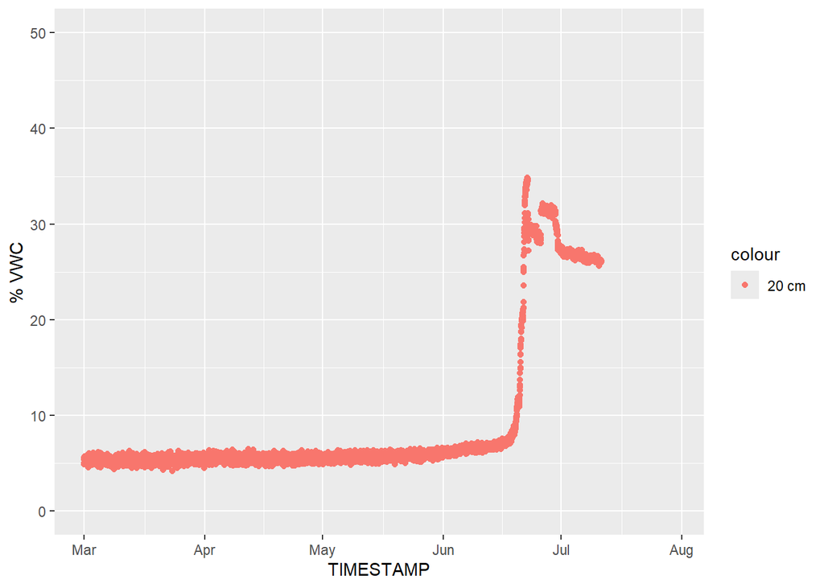

```r
VWC_20cm.limits = df$VWC_20cm

VWC_20cm.limits = ifelse(df$VWC_20cm == 0 ,NA, VWC_20cm.limits)

df$VWC_20cm.c = VWC_20cm.limits

# Check to see if values are removed

ggplot(data = df)+
  geom_point(aes(TIMESTAMP, VWC_20cm.c*100,col='20 cm'))+ # convert to percentage
  scale_y_continuous(limits = c(0,50),
                     expression('% VWC'))+
  scale_x_datetime(limits = as.POSIXct(biomet_dates,format="%F"))
```

##### Perm 20cm

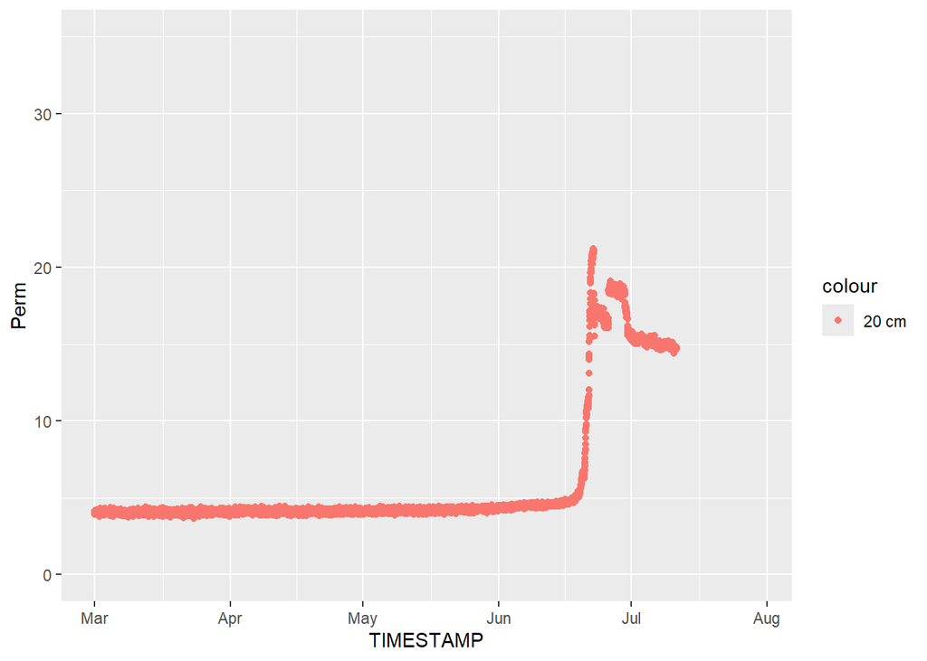

```r
ggplot(data = df)+
  geom_point(aes(TIMESTAMP, Perm_20cm ,col='20 cm'))+
  scale_y_continuous(limits = c(0,35),
                     expression('Perm'))+
  scale_x_datetime(limits = as.POSIXct(biomet_dates,format="%F"))
```

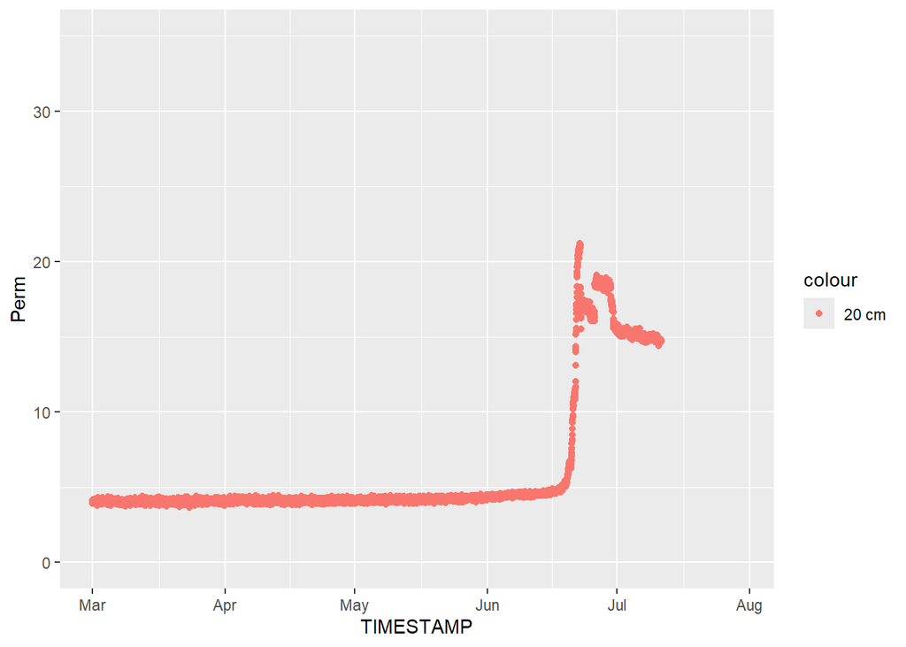

```r
Perm_20cm.limits = df$Perm_20cm

Perm_20cm.limits = ifelse(df$Perm_20cm == 0 & df$TIMESTAMP <= '2023-10-24' ,NA, Perm_20cm.limits)

df$Perm_20cm.c = Perm_20cm.limits

#check to see if values are removed
ggplot(data = df)+
  geom_point(aes(TIMESTAMP, Perm_20cm.c,col='20 cm'))+
  scale_y_continuous(limits = c(0,35),
                     expression('Perm'))+
  scale_x_datetime(limits = as.POSIXct(biomet_dates,format="%F"))
```